# MSC Beers - Full Data

## Вчитување, адаптација и анализа на податочниот сет

Импортирање на сите потребни библиотеки

```python
import math
import numpy as np
import pandas as pd
import matplotlib.pyplot as plt
import statsmodels.api as sm
import seaborn as sns
from sklearn.linear_model import LinearRegression
sns.set()
```

Вчитај го податочниот сет и испечати ги првите 5 записи

```python
beers_data = pd.read_csv('beer_reviews.csv')
beers_data.head()
```

|  | brewery_id | brewery_name | review_time | review_overall | review_aroma | review_appearance | review_profilename | beer_style | review_palate | review_taste | beer_name | beer_abv | beer_beerid |
| --- | --- | --- | --- | --- | --- | --- | --- | --- | --- | --- | --- | --- | --- |
| 0 | 10325 | Vecchio Birraio | 1234817823 | 1.5 | 2.0 | 2.5 | stcules | Hefeweizen | 1.5 | 1.5 | Sausa Weizen | 5.0 | 47986 |
| 1 | 10325 | Vecchio Birraio | 1235915097 | 3.0 | 2.5 | 3.0 | stcules | English Strong Ale | 3.0 | 3.0 | Red Moon | 6.2 | 48213 |
| 2 | 10325 | Vecchio Birraio | 1235916604 | 3.0 | 2.5 | 3.0 | stcules | Foreign / Export Stout | 3.0 | 3.0 | Black Horse Black Beer | 6.5 | 48215 |
| 3 | 10325 | Vecchio Birraio | 1234725145 | 3.0 | 3.0 | 3.5 | stcules | German Pilsener | 2.5 | 3.0 | Sausa Pils | 5.0 | 47969 |
| 4 | 1075 | Caldera Brewing Company | 1293735206 | 4.0 | 4.5 | 4.0 | johnmichaelsen | American Double / Imperial IPA | 4.0 | 4.5 | Cauldron DIPA | 7.7 | 64883 |

Колоната review_time е во unix timestamp формат т.е. секунди. За да можеме на граф временски да прикажеме кога се оставани оценките, вредностите на оваа колона треба да ги конвертираме во соодветен формат за датум и време.

```python
beers_data[ 'review_time' ] = pd.to_datetime( beers_data[ 'review_time' ], unit = 's' )
```

Во податoчниот сет оценките се оставани по повеќе категории и истиот не содржи просечна оценка. Ќе ја додадам средната оценка за да може полесно да ги визуелизирам оценките и да вршам препораки на основа на средна оценка.

Колоната review_average што ќе ја додадам ќе ја содржи реалната средна оценка со точност од една децимала. Ако се обидеме на граф да ја прикажеме распределбата на оценките на ваква скала, нема да добиеме очигледна информација бидејќи средната вредност теоретски ќе може да има 40 вредности (од 1.0 до 5.0). Пример: 1.9, 2.4, 4.3, 4.8 итн.

Колоната review_average_rounded ќе ја содржи средната оценка заокружена на скала од 0.5. Ова значи дека можните вредности за оваа колона ги намаливме на 9 и полесно ќе биде да вадиме заклучоци. Согласно погорниот пример, соодветни заокружени вредности би биле: 2, 2.5, 4.5, 5.0 итн.

```python
beers_data['review_average'] = beers_data.apply(lambda row: (row["review_overall"] + row["review_aroma"] +
                                                 row["review_appearance"] + row["review_palate"] +
                                                 row["review_taste"]) / 5, axis=1)

beers_data['review_average_rounded'] = beers_data.apply(lambda row: round(((row["review_overall"] + row["review_aroma"] +
                                                 row["review_appearance"] + row["review_palate"] +
                                                 row["review_taste"]) / 5)*2) / 2, axis=1)

beers_data = beers_data.drop(beers_data[(beers_data["review_average"] < 1) | (beers_data["review_average"] > 5)].index)

beers_data.head(5)
```

|  | brewery_id | brewery_name | review_time | review_overall | review_aroma | review_appearance | review_profilename | beer_style | review_palate | review_taste | beer_name | beer_abv | beer_beerid | review_average | review_average_rounded |
| --- | --- | --- | --- | --- | --- | --- | --- | --- | --- | --- | --- | --- | --- | --- | --- |
| 0 | 10325 | Vecchio Birraio | 2009-02-16 20:57:03 | 1.5 | 2.0 | 2.5 | stcules | Hefeweizen | 1.5 | 1.5 | Sausa Weizen | 5.0 | 47986 | 1.8 | 2.0 |
| 1 | 10325 | Vecchio Birraio | 2009-03-01 13:44:57 | 3.0 | 2.5 | 3.0 | stcules | English Strong Ale | 3.0 | 3.0 | Red Moon | 6.2 | 48213 | 2.9 | 3.0 |
| 2 | 10325 | Vecchio Birraio | 2009-03-01 14:10:04 | 3.0 | 2.5 | 3.0 | stcules | Foreign / Export Stout | 3.0 | 3.0 | Black Horse Black Beer | 6.5 | 48215 | 2.9 | 3.0 |
| 3 | 10325 | Vecchio Birraio | 2009-02-15 19:12:25 | 3.0 | 3.0 | 3.5 | stcules | German Pilsener | 2.5 | 3.0 | Sausa Pils | 5.0 | 47969 | 3.0 | 3.0 |
| 4 | 1075 | Caldera Brewing Company | 2010-12-30 18:53:26 | 4.0 | 4.5 | 4.0 | johnmichaelsen | American Double / Imperial IPA | 4.0 | 4.5 | Cauldron DIPA | 7.7 | 64883 | 4.2 | 4.0 |

Ќе го сменам и редоследот на колоните за поголема прегледност. Првин ќе дојдат колоните за пивниците и пивата, па потоа колоните со оценки и средни оценки и на крај колоните што содржат информација за тоа кој корисник и кога ги оставил оценките.

```python
beers_data = beers_data[['brewery_name', 'beer_style', 'beer_name',\
                         'beer_beerid', 'beer_abv', 'review_appearance', \
                         'review_aroma', 'review_palate', 'review_taste', \
                         'review_overall', 'review_average', 'review_average_rounded', \
                         'review_profilename', 'review_time']]
beers_data.head(5)
```

|  | brewery_name | beer_style | beer_name | beer_beerid | beer_abv | review_appearance | review_aroma | review_palate | review_taste | review_overall | review_average | review_average_rounded | review_profilename | review_time |
| --- | --- | --- | --- | --- | --- | --- | --- | --- | --- | --- | --- | --- | --- | --- |
| 0 | Vecchio Birraio | Hefeweizen | Sausa Weizen | 47986 | 5.0 | 2.5 | 2.0 | 1.5 | 1.5 | 1.5 | 1.8 | 2.0 | stcules | 2009-02-16 20:57:03 |
| 1 | Vecchio Birraio | English Strong Ale | Red Moon | 48213 | 6.2 | 3.0 | 2.5 | 3.0 | 3.0 | 3.0 | 2.9 | 3.0 | stcules | 2009-03-01 13:44:57 |
| 2 | Vecchio Birraio | Foreign / Export Stout | Black Horse Black Beer | 48215 | 6.5 | 3.0 | 2.5 | 3.0 | 3.0 | 3.0 | 2.9 | 3.0 | stcules | 2009-03-01 14:10:04 |
| 3 | Vecchio Birraio | German Pilsener | Sausa Pils | 47969 | 5.0 | 3.5 | 3.0 | 2.5 | 3.0 | 3.0 | 3.0 | 3.0 | stcules | 2009-02-15 19:12:25 |
| 4 | Caldera Brewing Company | American Double / Imperial IPA | Cauldron DIPA | 64883 | 7.7 | 4.0 | 4.5 | 4.0 | 4.5 | 4.0 | 4.2 | 4.0 | johnmichaelsen | 2010-12-30 18:53:26 |

Податочниот сет ни е всушност матрица од редови и колони. Колку редици и колони имаме можеме да провериме со следната функција.

```python
beers_data.shape
```

```
(1586614, 14)
```

Податочните типови на колоните од овој податочен сет се:

```python
beers_data.dtypes
```

```
brewery_name                      object
beer_style                        object
beer_name                         object
beer_beerid                        int64
beer_abv                         float64
review_appearance                float64
review_aroma                     float64
review_palate                    float64
review_taste                     float64
review_overall                   float64
review_average                   float64
review_average_rounded           float64
review_profilename                object
review_time               datetime64[ns]
dtype: object
```

Следно, ќе ги преставам податоците на временски графикон за да видам кога истите биле собирани.

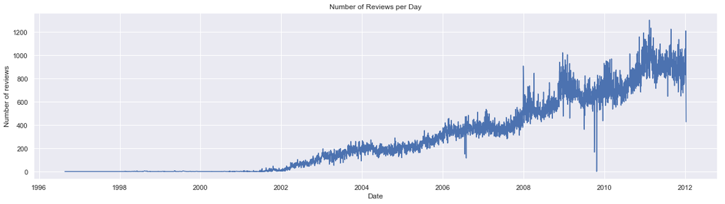

```python
group_by_date = beers_data[ [ 'review_time' ] ].groupby( beers_data[ 'review_time' ].dt.date ).agg( [ 'count' ] )
plt.figure( figsize = ( 20, 5 ) )
plt.plot( group_by_date )
plt.xlabel( 'Date' )
plt.ylabel( 'Number of reviews' )
plt.title( 'Number of Reviews per Day' )
plt.show()
```

Од графикот може да се забележи дека од 1996 кога е најстариот податок, до 2002 има многу малку податоци. Најголем дел од податоците се собрани од 2002 навака. Оценките пред 2002 бидејќи се во многу мал обем и би имале незначителен влог во крајните пресметки, ќе ги отстранам од податочниот сет.

```python
beers_data = beers_data.loc[ beers_data[ 'review_time' ].dt.year >= 2002 ]
```

Ќе го исцртам истиот граф за сега филтрираните податоци за да ја видиме временската дистрибуција на бројот на оценки по ден.

```python
beers_data.shape
```

```
(1584276, 14)
```

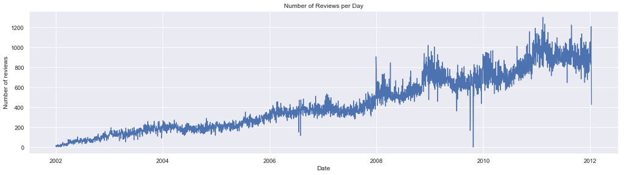

```python
group_by_date = beers_data[ [ 'review_time' ] ].groupby( beers_data[ 'review_time' ].dt.date ).agg( [ 'count' ] )
plt.figure( figsize = ( 20, 5 ) )
plt.plot( group_by_date )
plt.xlabel( 'Date' )
plt.ylabel( 'Number of reviews' )
plt.title( 'Number of Reviews per Day' )
plt.show()
```

Следно ќе ги опишам податоците. Од долната анализа не интересираат само сумарните резултати за колоните кои содржат оценки. Може да се забележи дека средна вредност на било која категорија оценки, е околу 4. Ваква вредност може да се очекува во секој податочен сет собиран од корисници онлајн кај кој можните оценки се во опсег од 1 до 5, т.е. сите податочни сетови слични на овој ќе имаат биас кон 4. Ова се должи најмногу на психолошкиот момент корисниците да го оценуваат само она што им се допаѓа, а да не губат време оставајќи оценки на работи што не им се допааат (се додека не се доволно изнервирани или немаат друга побуда да го направат истото).

```python
beers_data.describe()
```

|  | beer_beerid | beer_abv | review_appearance | review_aroma | review_palate | review_taste | review_overall | review_average | review_average_rounded |
| --- | --- | --- | --- | --- | --- | --- | --- | --- | --- |
| count | 1.584276e+06 | 1.516852e+06 | 1.584276e+06 | 1.584276e+06 | 1.584276e+06 | 1.584276e+06 | 1.584276e+06 | 1.584276e+06 | 1.584276e+06 |
| mean | 2.174216e+04 | 7.043847e+00 | 3.841683e+00 | 3.735744e+00 | 3.743738e+00 | 3.792758e+00 | 3.815449e+00 | 3.785874e+00 | 3.784204e+00 |
| std | 2.181984e+04 | 2.322902e+00 | 6.156712e-01 | 6.972328e-01 | 6.817895e-01 | 7.314830e-01 | 7.202830e-01 | 5.819321e-01 | 5.986468e-01 |
| min | 3.000000e+00 | 1.000000e-02 | 0.000000e+00 | 1.000000e+00 | 1.000000e+00 | 1.000000e+00 | 0.000000e+00 | 1.000000e+00 | 1.000000e+00 |
| 25% | 1.738000e+03 | 5.200000e+00 | 3.500000e+00 | 3.500000e+00 | 3.500000e+00 | 3.500000e+00 | 3.500000e+00 | 3.500000e+00 | 3.500000e+00 |
| 50% | 1.403300e+04 | 6.500000e+00 | 4.000000e+00 | 4.000000e+00 | 4.000000e+00 | 4.000000e+00 | 4.000000e+00 | 3.900000e+00 | 4.000000e+00 |
| 75% | 3.947800e+04 | 8.500000e+00 | 4.000000e+00 | 4.000000e+00 | 4.000000e+00 | 4.500000e+00 | 4.500000e+00 | 4.200000e+00 | 4.000000e+00 |
| max | 7.731700e+04 | 5.770000e+01 | 5.000000e+00 | 5.000000e+00 | 5.000000e+00 | 5.000000e+00 | 5.000000e+00 | 5.000000e+00 | 5.000000e+00 |

Анализа на уникатноста на пивата. Интересно е што во податочниот сет има многу пива со исто име што се различни (различно id). Тоа може да се види од следната пресметка.

```python
print( 'Уникатни пива' )
print( 'По id:', beers_data[ 'beer_beerid' ].nunique() )
print( 'По име:', beers_data[ 'beer_name' ].nunique() )
```

```
Уникатни пива
По id: 65915
По име: 56748
```

Имајќи 65915 различни пива и околу 1.5 милиони оценки, би очекувале секое пиво да има во просек 23 оценки. Да ја провериме оваа информација.

```python
beer_reviews = beers_data['beer_beerid'].value_counts().reset_index()
beer_reviews.columns = ['beerid', 'number_of_reviews']
beer_reviews.describe().number_of_reviews
```

```
count    65915.000000
mean        24.035136
std        110.798501
min          1.000000
25%          1.000000
50%          2.000000
75%          7.000000
max       3289.000000
Name: number_of_reviews, dtype: float64
```

Од овој опис се гледа дека не е така.

Всушност само 25% од пивата ќе имаат повеќе од 7 оценки, додека половина од нив ќе имаат едвај по 2 оценки.

Како и да е, постојат популарни пива со илјадници оценки.

Ако ги подредиме по број на оценки, првите десет пива со најмногу оценки и последните 5 пива со најмалку оценки се следните.

```python
beer_reviews = beers_data['beer_name'].value_counts().reset_index()
beer_reviews.columns = ['beer_name', 'number_of_reviews']
```

Најмногу оценувани 10 пива

```python
beer_reviews.head(10)
```

|  | beer_name | number_of_reviews |
| --- | --- | --- |
| 0 | 90 Minute IPA | 3289 |
| 1 | India Pale Ale | 3126 |
| 2 | Old Rasputin Russian Imperial Stout | 3098 |
| 3 | Sierra Nevada Celebration Ale | 2987 |
| 4 | Two Hearted Ale | 2727 |
| 5 | Stone Ruination IPA | 2704 |
| 6 | Arrogant Bastard Ale | 2699 |
| 7 | Sierra Nevada Pale Ale | 2577 |
| 8 | Stone IPA (India Pale Ale) | 2574 |
| 9 | Pliny The Elder | 2527 |

Најмалку оценувани 5 пива

```python
beer_reviews.tail(5)
```

|  | beer_name | number_of_reviews |
| --- | --- | --- |
| 56743 | Hurricane Kitty Aged In Rye Whiskey Barrel | 1 |
| 56744 | Ballistic Brewing Co. - Bumblebee Golden Ale | 1 |
| 56745 | Hoster 90 Shilling Scottish Ale | 1 |
| 56746 | Old Curmudgeon Barley Wine | 1 |
| 56747 | Irish Baghandler | 1 |

Анализа на корисниците. Колку различни корисници имаат оставено оценки и колку од различните корисници имаат оставено барем две оценки.

```python
unique_users = beers_data[ 'review_profilename' ].nunique()
unique_users_with_one_review = float(beers_data[ 'review_profilename' ]\
                                     .value_counts()\
                                     [ beers_data[ 'review_profilename' ].value_counts() > 1 ]\
                                     .shape[0])
unique_users_with_one_review_percentage = round( unique_users_with_one_review / unique_users, 2 ) * 100

print( 'Уникатни корисници:',  unique_users)
print( 'Уникатни корисници со повеќе од една оценка:',  unique_users_with_one_review)
print( 'Уникатни корисници со повеќе од една оценка во %: ',   unique_users_with_one_review_percentage)
```

```
Уникатни корисници: 33374
Уникатни корисници со повеќе од една оценка: 22934.0
Уникатни корисници со повеќе од една оценка во %:  69.0
```

Бидејќи податочниот сет има околу 1.5 милиони оценки и 33374 корисници, би очекувале дека во просек секој корисник има оставено по 50тина оценки.

```python
user_reviews = beers_data['review_profilename'].value_counts().reset_index()
user_reviews.columns = ['profilename', 'number_of_reviews']
user_reviews.describe().number_of_reviews
```

```
count    33374.000000
mean        47.459939
std        182.345710
min          1.000000
25%          1.000000
50%          3.000000
75%         16.000000
max       5817.000000
Name: number_of_reviews, dtype: float64
```

Од погорниот опис на корисниците може да се види дека ова и тука не е случај.

Само 25% корисниците имаат оставено над 16 оценки, додека половина од нив во просек оставиле по 3 оценки.

Има и ентузијасти кои имаат оставено илјадници оценки на различни пива.

Ако ги подредиме по број на оставени оценки, корисниците со најмногу и најмалку оценки се следните:

```python
user_reviews = beers_data[ 'review_profilename' ].value_counts().reset_index()
user_reviews.columns = ['profilename', 'number_of_reviews']
```

Корисници со најмногу оценки

```python
user_reviews.head(10)
```

|  | profilename | number_of_reviews |
| --- | --- | --- |
| 0 | northyorksammy | 5817 |
| 1 | BuckeyeNation | 4661 |
| 2 | mikesgroove | 4617 |
| 3 | Thorpe429 | 3518 |
| 4 | womencantsail | 3497 |
| 5 | NeroFiddled | 3488 |
| 6 | ChainGangGuy | 3471 |
| 7 | brentk56 | 3357 |
| 8 | Phyl21ca | 3179 |
| 9 | WesWes | 3168 |

Корисници со најмалку оценки

```python
user_reviews.tail(5)
```

|  | profilename | number_of_reviews |
| --- | --- | --- |
| 33369 | sugarmuffin88 | 1 |
| 33370 | IrishMalt | 1 |
| 33371 | Craftbrewlvr | 1 |
| 33372 | TheImperial | 1 |
| 33373 | fairwaybunker | 1 |

## Визуелизација на распределбата на оценките

Првин табеларно ќе ги групирам оценките по вкупен број на оценки за секоја вредност од 1.0 до 5.0 со стапка од 0.5.

```python
group_by_review_overall = beers_data[ 'review_overall' ]\
                            .value_counts( dropna = False )\
                            .reset_index()\
                            .rename( columns = { 'index' : 'review', 'review_overall' : 'overall' } )\
                            .sort_values( by = 'review' )
group_by_review_aroma = beers_data[ 'review_aroma' ]\
                            .value_counts( dropna = False )\
                            .reset_index()\
                            .rename( columns = { 'index' : 'review', 'review_aroma' : 'aroma' } )\
                            .sort_values( by = 'review' )
group_by_review_appearance = beers_data[ 'review_appearance' ]\
                            .value_counts( dropna = False )\
                            .reset_index()\
                            .rename( columns = { 'index' : 'review', 'review_appearance' : 'appearance' } )\
                            .sort_values( by = 'review' )
group_by_review_palate = beers_data[ 'review_palate' ]\
                            .value_counts( dropna = False )\
                            .reset_index()\
                            .rename( columns = { 'index' : 'review', 'review_palate' : 'palate' } )\
                            .sort_values( by = 'review' )
group_by_review_taste = beers_data[ 'review_taste' ]\
                            .value_counts( dropna = False )\
                            .reset_index()\
                            .rename( columns = { 'index' : 'review', 'review_taste' : 'taste' } )\
                            .sort_values( by = 'review' )
group_by_review_average = beers_data[ 'review_average_rounded' ]\
                            .value_counts( dropna = False )\
                            .reset_index()\
                            .rename( columns = { 'index' : 'review', 'review_average_rounded' : 'average' } )\
                            .sort_values( by = 'review' )

group_by_review_overall[ 'review' ] = group_by_review_overall[ 'review' ].astype( str )
group_by_review_aroma[ 'review' ] = group_by_review_aroma[ 'review' ].astype( str )
group_by_review_appearance[ 'review' ] = group_by_review_appearance[ 'review' ].astype( str )
group_by_review_palate[ 'review' ] = group_by_review_palate[ 'review' ].astype( str )
group_by_review_taste[ 'review' ] = group_by_review_taste[ 'review' ].astype( str )
group_by_review_average[ 'review' ] = group_by_review_average[ 'review' ].astype( str )

group_by_review = group_by_review_overall.merge( group_by_review_aroma, how = 'outer', on = [ 'review' ] )
group_by_review = group_by_review.merge( group_by_review_appearance, how = 'outer', on = [ 'review' ] )
group_by_review = group_by_review.merge( group_by_review_palate, how = 'outer', on = [ 'review' ] )
group_by_review = group_by_review.merge( group_by_review_taste, how = 'outer', on = [ 'review' ] )
group_by_review = group_by_review.merge( group_by_review_average, how = 'outer', on = [ 'review' ] )
group_by_review = group_by_review.fillna( 0 )
group_by_review
```

|  | review | overall | aroma | appearance | palate | taste | average |
| --- | --- | --- | --- | --- | --- | --- | --- |
| 0 | 0.0 | 7 | 0.0 | 7 | 0.0 | 0.0 | 0.0 |
| 1 | 1.0 | 10893 | 6807.0 | 3279 | 6808.0 | 9911.0 | 2425.0 |
| 2 | 1.5 | 12972 | 12521.0 | 6146 | 11044.0 | 15127.0 | 8860.0 |
| 3 | 2.0 | 38111 | 42402.0 | 25316 | 38179.0 | 41837.0 | 23607.0 |
| 4 | 2.5 | 58513 | 66349.0 | 39477 | 62828.0 | 66513.0 | 56362.0 |
| 5 | 3.0 | 165292 | 199477.0 | 165528 | 206423.0 | 166498.0 | 153972.0 |
| 6 | 3.5 | 301725 | 365166.0 | 318391 | 338465.0 | 324428.0 | 378230.0 |
| 7 | 4.0 | 581749 | 556423.0 | 673144 | 605739.0 | 540602.0 | 662802.0 |
| 8 | 4.5 | 324222 | 271348.0 | 288009 | 252981.0 | 335964.0 | 271259.0 |
| 9 | 5.0 | 90792 | 63783.0 | 64979 | 61809.0 | 83396.0 | 26759.0 |

Истиот овој податок, наместо во табела, прикажан на графикон е даден подолу.

```python
def plotPerColumnDistribution(df, nGraphShown, nGraphPerRow):
    nunique = df.nunique()
    df = df[[col for col in df if nunique[col] > 1 and nunique[col] < 50 and col != 'review_average']]
    nRow, nCol = df.shape
    columnNames = list(df)
    nGraphRow = (nCol + nGraphPerRow - 1) / nGraphPerRow
    plt.figure(num = None, figsize = (6 * nGraphPerRow, 6 * nGraphRow), dpi = 80, facecolor = 'w', edgecolor = 'k')
    for i in range(min(nCol, nGraphShown)):
        plt.subplot(nGraphRow, nGraphPerRow, i + 1)
        columnDf = df.iloc[:, i]
        if (not np.issubdtype(type(columnDf.iloc[0]), np.number)):
            valueCounts = columnDf.value_counts()
            valueCounts.plot.bar()
        else:
            columnDf.hist()
        plt.ylabel('counts')
        plt.xticks(rotation = 90)
        plt.title({columnNames[i]})
    plt.tight_layout(pad = 1.0, w_pad = 1.0, h_pad = 1.0)
    plt.show()
```

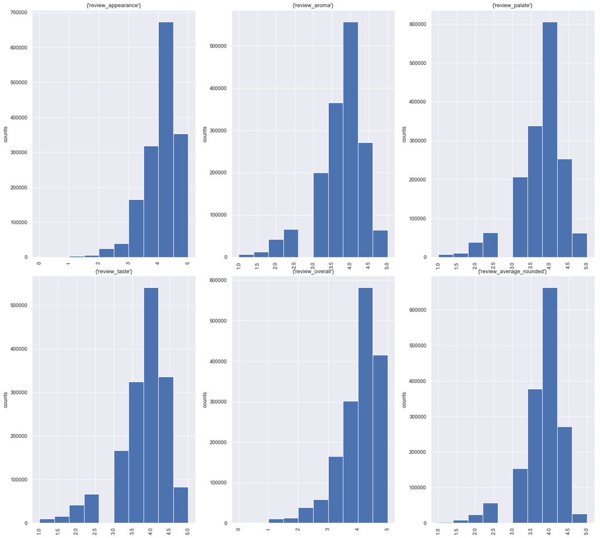

```python
plotPerColumnDistribution(beers_data, 10, 3)
```

Следната табела ни ја сумира распределбата на оценки по пиво. За секое од пивата имаме нова колона number_of_reviews, која содржи информација колку вкупно оценки има за секое од пивата, а останатите колони кои што ги прикажуваат оценките ги содржат средните вредности од поедниечните оценки.

```python
grouped_beers_data = beers_data.groupby( [ 'beer_name', 'brewery_name', 'beer_style', 'beer_abv' ] ) \
    .agg( { 'review_overall' : 'mean', 'review_aroma' : 'mean', 'review_appearance' : 'mean', \
            'review_palate' : 'mean', 'review_taste' : 'mean', 'review_average_rounded' : 'mean', \
            'review_profilename' : 'count' } ).reset_index() \
    .rename( columns = { 'review_profilename' : 'number_of_reviews' } )
grouped_beers_data.head()
```

|  | beer_name | brewery_name | beer_style | beer_abv | review_overall | review_aroma | review_appearance | review_palate | review_taste | review_average_rounded | number_of_reviews |
| --- | --- | --- | --- | --- | --- | --- | --- | --- | --- | --- | --- |
| 0 | ! (Old Ale) | Närke Kulturbryggeri AB | Old Ale | 8.2 | 4.0 | 4.5 | 4.00 | 4.000000 | 4.5 | 4.00 | 1 |
| 1 | "100" | The Covey Restaurant & Brewery | Belgian Dark Ale | 10.0 | 4.0 | 4.0 | 4.00 | 4.000000 | 4.4 | 4.00 | 5 |
| 2 | "100" Pale Ale | Aviator Brewing Company | American IPA | 6.6 | 4.0 | 4.0 | 3.50 | 4.000000 | 4.0 | 4.00 | 1 |
| 3 | "12" Belgian Golden Strong Ale | Flossmoor Station Restaurant & Brewery | Belgian Strong Pale Ale | 9.0 | 4.0 | 3.5 | 4.25 | 4.750000 | 4.5 | 4.25 | 2 |
| 4 | "33" Export | Baltika-Baku | Dortmunder / Export Lager | 4.8 | 3.0 | 3.0 | 3.00 | 3.166667 | 3.0 | 3.00 | 3 |

Најди ги првите 5 пива со најмногу оценки.

```python
grouped_beers_data.sort_values( by = 'number_of_reviews', ascending = False ).head(5)
```

|  | beer_name | brewery_name | beer_style | beer_abv | review_overall | review_aroma | review_appearance | review_palate | review_taste | review_average_rounded | number_of_reviews |
| --- | --- | --- | --- | --- | --- | --- | --- | --- | --- | --- | --- |
| 731 | 90 Minute IPA | Dogfish Head Brewery | American Double / Imperial IPA | 9.0 | 4.145789 | 4.213591 | 4.192156 | 4.181514 | 4.326087 | 4.212831 | 3288 |
| 31841 | Old Rasputin Russian Imperial Stout | North Coast Brewing Co. | Russian Imperial Stout | 9.0 | 4.172853 | 4.197385 | 4.373467 | 4.231278 | 4.340058 | 4.264203 | 3097 |
| 39557 | Sierra Nevada Celebration Ale | Sierra Nevada Brewing Co. | American IPA | 6.8 | 4.166890 | 4.081687 | 4.224138 | 4.073318 | 4.186977 | 4.137931 | 2986 |
| 45123 | Two Hearted Ale | Bell's Brewery, Inc. | American IPA | 7.0 | 4.329483 | 4.266227 | 4.153649 | 4.138431 | 4.318665 | 4.245141 | 2726 |
| 41835 | Stone Ruination IPA | Stone Brewing Co. | American Double / Imperial IPA | 7.7 | 4.161612 | 4.341531 | 4.179179 | 4.183432 | 4.351331 | 4.242234 | 2702 |

Најди ги првите 5 пива со највисока средна оценка.

```python
grouped_beers_data.sort_values( by = 'review_average_rounded', ascending = False ).head(5)
```

|  | beer_name | brewery_name | beer_style | beer_abv | review_overall | review_aroma | review_appearance | review_palate | review_taste | review_average_rounded | number_of_reviews |
| --- | --- | --- | --- | --- | --- | --- | --- | --- | --- | --- | --- |
| 9832 | Celtic Red | Milwaukee Ale House | Irish Red Ale | 5.0 | 5.0 | 4.5 | 4.5 | 5.0 | 5.0 | 5.0 | 1 |
| 16163 | Five Generations | W. J. King & Co. Brewers | English Bitter | 4.4 | 5.0 | 4.5 | 5.0 | 5.0 | 4.5 | 5.0 | 1 |
| 5012 | Bert's Best Bitter | John Harvard's Brewery & Ale House | English Bitter | 4.7 | 5.0 | 5.0 | 4.5 | 5.0 | 4.5 | 5.0 | 1 |
| 37712 | Saint Slater Irish Stout | Thr3e Wise Men | Irish Dry Stout | 5.4 | 5.0 | 4.5 | 5.0 | 5.0 | 5.0 | 5.0 | 1 |
| 8212 | Brooklyn Manchester Star | Brooklyn Brewery | Baltic Porter | 7.0 | 5.0 | 4.5 | 4.5 | 5.0 | 5.0 | 5.0 | 1 |

Овде ќе наидеме на проблем со начинот на кој ги групирав пивата погоре. Бидејќи ги групирав по средна вредност, значи дека ако едно пиво има само една оценка: 5, а друго пиво има илјада оценки со просечна вредност: 4.5, ние ќе го видиме првото како подобро рангирано од второто.

Во групираните податоци од погоре, имаме информации за бројот на рејтинзи на секое пиво како и средна оценка од тие рејтинзи. Ако ова го претставиме на дводимензионален дијаграм т.н. scatter plot, јасно ќе го видиме проблемот.

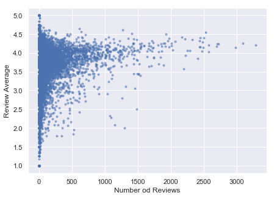

```python
plt.figure( figsize = ( 7, 5 ) )
plt.scatter( grouped_beers_data[ 'number_of_reviews' ], \
            grouped_beers_data[ 'review_average_rounded' ], \
            marker ='.', alpha = .5 )
plt.xlabel( 'Number od Reviews' )
plt.ylabel( 'Review Average' )
plt.show()
```

```python
grouped_beers_data.sort_values( by = 'review_average_rounded', ascending = False ).head( 5 )
```

|  | beer_name | brewery_name | beer_style | beer_abv | review_overall | review_aroma | review_appearance | review_palate | review_taste | review_average_rounded | number_of_reviews |
| --- | --- | --- | --- | --- | --- | --- | --- | --- | --- | --- | --- |
| 9832 | Celtic Red | Milwaukee Ale House | Irish Red Ale | 5.0 | 5.0 | 4.5 | 4.5 | 5.0 | 5.0 | 5.0 | 1 |
| 16163 | Five Generations | W. J. King & Co. Brewers | English Bitter | 4.4 | 5.0 | 4.5 | 5.0 | 5.0 | 4.5 | 5.0 | 1 |
| 5012 | Bert's Best Bitter | John Harvard's Brewery & Ale House | English Bitter | 4.7 | 5.0 | 5.0 | 4.5 | 5.0 | 4.5 | 5.0 | 1 |
| 37712 | Saint Slater Irish Stout | Thr3e Wise Men | Irish Dry Stout | 5.4 | 5.0 | 4.5 | 5.0 | 5.0 | 5.0 | 5.0 | 1 |
| 8212 | Brooklyn Manchester Star | Brooklyn Brewery | Baltic Porter | 7.0 | 5.0 | 4.5 | 4.5 | 5.0 | 5.0 | 5.0 | 1 |

За да го решиме овој проблем, наместо при групирањето на оценките по пиво да ги групирам истите по средна вредност, ќе искористам посовремен метод, кој ќе додава тежина врз основа на бројот на оценки и на тој начин ќе ги скалира истите. Недостигот овде е што ќе се изгуби јасна видливост за секое од пивата колку му се средните оценки, ама пак ќе им ја намалам вредноста на пивата со малку оценки во конечниот сет.

Посовремениот метод што го спомнав е имплементација на Вилсонов интервал на доверба за Бернулиев параметар и е надвор од темата на истражување на овој труд. Неговата имплементација е дадена во следните 2 функции.

Повеќе информации: http://www.evanmiller.org/how-not-to-sort-by-average-rating.html

```python
# pos: number of positive ratings
# n: total number of ratings
def ci_lower_bound( pos, n ):
    if n == 0:
        return 0
    z = 1.96
    phat = 1.0 * pos / n
    return ( phat + ( z ** 2 ) / ( 2 * n ) - z * math.sqrt( ( phat * ( 1 - phat ) + ( z ** 2 ) / ( 4 * n ) ) / n ) )\
            / ( 1 + ( z ** 2 ) / n )

# Aggregation function for reviews
# Positive reviews are defined as a constant fraction of their real value
# Aggregation is performed using the Lower bound of Wilson score confidence interval for a Bernoulli parameter
def agg_reviews( reviews ):
    pos = 0
    for index, review in reviews[ reviews >= 3 ].iteritems():
        pos += review / 5

    return ci_lower_bound( pos, reviews.shape[ 0 ] ) * 5
```

После ова групираниот податочен од погоре, ќе изгледа вака:

```python
# Grouping beers and aggregating reviews
grouped_beers_data = beers_data.groupby( [ 'beer_name', 'brewery_name', 'beer_style', 'beer_abv' ] ) \
    .agg( { 'review_overall' : agg_reviews, 'review_aroma' : agg_reviews, 'review_appearance' : agg_reviews,\
            'review_palate' : agg_reviews, 'review_taste' : agg_reviews, 'review_average_rounded' : agg_reviews, \
            'review_profilename' : 'count' } ).reset_index() \
    .rename( columns = { 'review_profilename' : 'number_of_reviews' } )
grouped_beers_data.head()
```

|  | beer_name | brewery_name | beer_style | beer_abv | review_overall | review_aroma | review_appearance | review_palate | review_taste | review_average_rounded | number_of_reviews |
| --- | --- | --- | --- | --- | --- | --- | --- | --- | --- | --- | --- |
| 0 | ! (Old Ale) | Närke Kulturbryggeri AB | Old Ale | 8.2 | 0.667301 | 0.838581 | 0.667301 | 0.667301 | 0.838581 | 0.667301 | 1 |
| 1 | "100" | The Covey Restaurant & Brewery | Belgian Dark Ale | 10.0 | 1.877641 | 1.877641 | 1.877641 | 1.877641 | 2.222222 | 1.877641 | 5 |
| 2 | "100" Pale Ale | Aviator Brewing Company | American IPA | 6.6 | 0.667301 | 0.667301 | 0.516744 | 0.667301 | 0.667301 | 0.667301 | 1 |
| 3 | "12" Belgian Golden Strong Ale | Flossmoor Station Restaurant & Brewery | Belgian Strong Pale Ale | 9.0 | 1.115248 | 0.871326 | 1.249653 | 1.546871 | 1.393219 | 1.249653 | 2 |
| 4 | "33" Export | Baltika-Baku | Dortmunder / Export Lager | 4.8 | 0.862406 | 0.487809 | 0.862406 | 0.948425 | 0.487809 | 0.862406 | 3 |

Ако после ова ги покажеме групните податоци на scatter plot дијаграмот, јасно ќе ја видиме разликата.

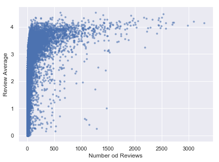

```python
plt.figure( figsize = ( 7, 5 ) )
plt.scatter( grouped_beers_data[ 'number_of_reviews' ],\
            grouped_beers_data[ 'review_average_rounded' ],\
            marker ='.', alpha = .5 )
plt.xlabel( 'Number od Reviews' )
plt.ylabel( 'Review Average' )
plt.show()
```

```python
grouped_beers_data.sort_values( by = 'review_average_rounded', ascending = False ).head( 5 )
```

|  | beer_name | brewery_name | beer_style | beer_abv | review_overall | review_aroma | review_appearance | review_palate | review_taste | review_average_rounded | number_of_reviews |
| --- | --- | --- | --- | --- | --- | --- | --- | --- | --- | --- | --- |
| 44523 | Trappist Westvleteren 12 | Brouwerij Westvleteren (Sint-Sixtusabdij van W... | Quadrupel (Quad) | 10.2 | 4.530716 | 4.495034 | 4.354817 | 4.539659 | 4.646554 | 4.524758 | 1272 |
| 34257 | Pliny The Younger | Russian River Brewing Company | American Double / Imperial IPA | 11.0 | 4.474180 | 4.618422 | 4.349282 | 4.492465 | 4.615607 | 4.523674 | 610 |
| 34256 | Pliny The Elder | Russian River Brewing Company | American Double / Imperial IPA | 8.0 | 4.525157 | 4.555939 | 4.317931 | 4.380363 | 4.569367 | 4.478398 | 2527 |
| 16542 | Founders CBS Imperial Stout | Founders Brewing Company | American Double / Imperial Stout | 10.6 | 4.461236 | 4.431703 | 4.324919 | 4.458626 | 4.586989 | 4.442113 | 637 |
| 43386 | The Abyss | Deschutes Brewery | American Double / Imperial Stout | 11.0 | 4.348464 | 4.345835 | 4.516398 | 4.416251 | 4.498497 | 4.428719 | 1412 |

Имајќи ги групирано податоците погоре минимизирајќи го учеството на пива со мал број на рејтинзи, сега лесно може да се генерираат едноставни заклучоци и препораки и без имплемeнтирање на алгоритми за длабоко учење.

```python
grouped_beers_data.sort_values( by = [ 'review_aroma', 'review_appearance' ], ascending = False ).head( 10 ) \
    [ 'beer_style' ].unique().tolist()
```

```
['American Double / Imperial IPA',
 'American Double / Imperial Stout',
 'Quadrupel (Quad)',
 'Russian Imperial Stout']
```

Следно ќе ја претставам распределбата на пива според промили алкохол во секое од нив. Колоната во податочниот сет е abv (alcohol by volume)

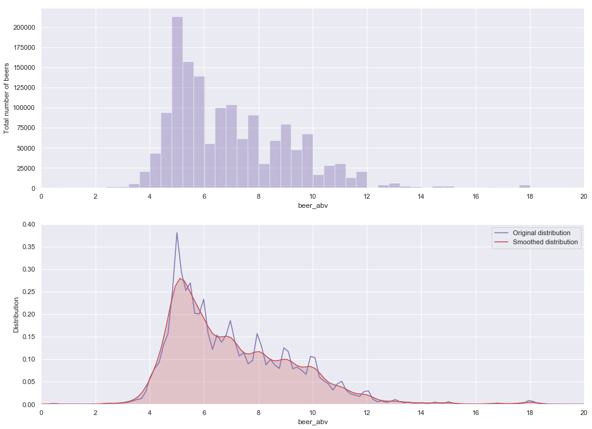

```python
beer_data_low_than_20_abv = beers_data.drop(beers_data[beers_data["beer_abv"] > 20].index).dropna()

sns.set(rc={"axes.grid": True})
fig, axs = plt.subplots(nrows=2, figsize=[16, 12])
plt.setp(axs, xticks=range(0, 21, 2))

sns.distplot(beer_data_low_than_20_abv["beer_abv"], bins=50, ax=axs[0], kde=False, color="m")
sns.kdeplot(beer_data_low_than_20_abv["beer_abv"], ax=axs[1], color="m", label="Original distribution")
sns.kdeplot(beer_data_low_than_20_abv["beer_abv"], ax=axs[1], color="r", bw=0.3, shade=True, label="Smoothed distribution")

axs[0].set_xlim(0, 20)
axs[0].set_ylabel("Total number of beers")

axs[1].set_xlim(0, 20)
axs[1].set_xlabel("beer_abv")
axs[1].set_ylabel("Distribution");
```

За крај од анализата на податоци, ќе извадам уште еден групен податочен сет, без оценки, за да извадиме податоци за тоа која пивница има најмногу пива, од кој стил на пиво има најмногу пива и кои фактори (арома, вкус, изглед, доживување) најмногу влијаат во определување на општата оценка на дадено пиво. Овие информации ќе ни се најдат полезни при толкувањето на резултатите што ќе ги генерираат алгоритмите подолу.

```python
beers_only_data = beers_data[ [ 'beer_name', 'brewery_name', 'beer_style', 'beer_abv' ] ].drop_duplicates()
beers_only_data.shape
```

```
(65728, 4)
```

Која пивница колку пива има произведено? Покажи ги првите 10.

```python
beers_only_data[ 'brewery_name' ].value_counts( dropna = False ).head(10)
```

```
Rock Bottom Restaurant & Brewery      875
John Harvard's Brewery & Ale House    390
Goose Island Beer Co.                 368
Iron Hill Brewery & Restaurant        316
Minneapolis Town Hall Brewery         312
Port Brewing Company / Pizza Port     283
Cigar City Brewing                    201
Mikkeller ApS                         185
Kuhnhenn Brewing Company              177
Sly Fox Brewing Company               175
Name: brewery_name, dtype: int64
```

Од кој стил има најмногу пива? Покажи ги првите 10.

```python
beers_only_data[ 'beer_style' ].value_counts( dropna = False ).head(10)
```

```
American IPA                      3592
American Pale Ale (APA)           3311
American Amber / Red Ale          2496
American Porter                   2180
Fruit / Vegetable Beer            1826
Hefeweizen                        1719
American Double / Imperial IPA    1547
English Bitter                    1483
Euro Pale Lager                   1479
American Stout                    1420
Name: beer_style, dtype: int64
```

Кој фактор најмногу влијае во генералната оценка на дадено пиво?

```python
# Дефинирање линеарен модел
linear_model = LinearRegression( normalize = True )
```

```python
# Тренирање на линеарен модел и генерирање на препораки
linear_model.fit( X = beers_data[ [ 'review_aroma', 'review_appearance', 'review_palate', 'review_taste' ] ],\
                  y = beers_data[ 'review_overall' ] )
preds = linear_model.predict( beers_data[ [ 'review_aroma', 'review_appearance', 'review_palate', 'review_taste' ] ] )
```

```python
# Коефициенти за секоја категорија (арома, изглед, доживување, вкус)
linear_model.coef_
```

```
array([0.04775205, 0.03561118, 0.25846474, 0.55172152])
```

Од добиените коефициенти по правење на линеарна коералција меѓу секој од факторите со генералната оценка, може да се заклучи дека најмногу влијае вкусот (taste), па доживувањето (palate), па аромата (aroma) и на крај најмал удел има изгледот на дадено пиво (appearance). Овие резултати се и очекувани резултати во овој домен на работа.

## Имплементација на алгоритам за препораки

### Модел со matrix factorization

Имајќи податочен сет кој содржи директна врска меѓу корисник, пиво и оценката за даден корисник за дадено пиво, проблемот на препорака користејќи пристап со matrix factorization се сведува на ниво на проблем на линеарна регресија. Моделот што ќе го дефинирам треба за дадено пиво да погоди дали ќе му се допадне на даден корисник или не. Идејата е таа од фактот што на корисникот треба секогаш да му понудиме пиво кое би го оценил со висока оценка.

За алгоритмот да работи во keras, треба да направам мапирање на сите вредности на колоната beer_id да бидат во опсегот помеѓу 0 и вкупниот број на пива. Исто така, колоната review_profilename треба да биде мапирана во нумерички вредности и тоа помеѓу 0 и вкупниот број на корисници.

```python
users = beers_data.review_profilename.unique()
user_map = {i:val for i,val in enumerate(users)}
inverse_user_map = {val:i for i,val in enumerate(users)}
beers = beers_data.beer_beerid.unique()
beer_map = {i:val for i,val in enumerate(beers)}
inverse_beer_map = {val:i for i,val in enumerate(beers)}

beers_data.loc[:,"user_id"] = beers_data["review_profilename"].map(inverse_user_map)
beers_data.loc[:,"beer_id"] = beers_data["beer_beerid"].map(inverse_beer_map)

print("Има %d корисници"%users.shape[0])
print("Има %d пива"%beers.shape[0])
beers_data.head()
```

```
Има 33375 корисници
Има 65915 пива
```

|  | brewery_name | beer_style | beer_name | beer_beerid | beer_abv | review_appearance | review_aroma | review_palate | review_taste | review_overall | review_average | review_average_rounded | review_profilename | review_time | user_id | beer_id |
| --- | --- | --- | --- | --- | --- | --- | --- | --- | --- | --- | --- | --- | --- | --- | --- | --- |
| 0 | Vecchio Birraio | Hefeweizen | Sausa Weizen | 47986 | 5.0 | 2.5 | 2.0 | 1.5 | 1.5 | 1.5 | 1.8 | 2.0 | stcules | 2009-02-16 20:57:03 | 0 | 0 |
| 1 | Vecchio Birraio | English Strong Ale | Red Moon | 48213 | 6.2 | 3.0 | 2.5 | 3.0 | 3.0 | 3.0 | 2.9 | 3.0 | stcules | 2009-03-01 13:44:57 | 0 | 1 |
| 2 | Vecchio Birraio | Foreign / Export Stout | Black Horse Black Beer | 48215 | 6.5 | 3.0 | 2.5 | 3.0 | 3.0 | 3.0 | 2.9 | 3.0 | stcules | 2009-03-01 14:10:04 | 0 | 2 |
| 3 | Vecchio Birraio | German Pilsener | Sausa Pils | 47969 | 5.0 | 3.5 | 3.0 | 2.5 | 3.0 | 3.0 | 3.0 | 3.0 | stcules | 2009-02-15 19:12:25 | 0 | 3 |
| 4 | Caldera Brewing Company | American Double / Imperial IPA | Cauldron DIPA | 64883 | 7.7 | 4.0 | 4.5 | 4.0 | 4.5 | 4.0 | 4.2 | 4.0 | johnmichaelsen | 2010-12-30 18:53:26 | 1 | 4 |

За да ја оценам успешноста на овој алгоритам, ќе го поделам податочниот сет во 2 дела, тренинг и тестинг сет. Првиот ќе му служи на алгоритамот за да ја научи корелацијата меѓу оценките, корисниците и пивата, а вториот за да да видиме дали имајќи ги само корисниците и пивата, може да ги предвиди оценките.

За пресметките подолу ќе ги користам tensor flow и keras библиотеките за python програмскиот јазик.

```python
from sklearn.model_selection import train_test_split

ratings_train, ratings_test = train_test_split(
    beers_data, test_size=0.2, random_state=0)
```

```python
import tensorflow as tf
```

```python
from keras.backend.tensorflow_backend import set_session
config = tf.ConfigProto()
config.gpu_options.per_process_gpu_memory_fraction
config.gpu_options.visible_device_list = "0" # "0,1"
set_session(tf.Session(config=config))
```

```python
from keras.models import Model
from keras.layers import Input
from keras.layers.core import Reshape
from keras.layers.merge import Multiply
from keras.layers.merge import Dot
from keras.layers.embeddings import Embedding
from keras import optimizers
```

Првин ќе имплементирам алгоритам за препорака базиран на matrix-factorization. За таа цел се потребни два Embedding-а, едниот за корисниците, другиот за пивата. Матричниот производ помеѓу корисник и пиво ќе ја даде претпоставената оценка на корисникот K за пивото P.

Код за зачувување на моделите и нивните перфоманси.

```python
import time
from keras.callbacks import ModelCheckpoint
mainpath = 'C:\\Users\\pesovski\\Anaconda2\\envs\\ip\\beer_recommendation'
save_path = mainpath + "\\models"
mytime = time.strftime("%Y_%m_%d_%H_%M")
modname = 'matrix_factorization_10_' + mytime
thename = save_path + '\\' + modname + '.h5'
mcheck = ModelCheckpoint(thename  , monitor='val_loss', save_best_only=True)
```

Дефинирање на модел во keras

```python
user_id_input = Input(shape=[1], name='user')
item_id_input = Input(shape=[1], name='item')
```

Тренирање на моделот со embedding_size=10, 100 епохи

```python
embedding_size = 10
user_embedding = Embedding(output_dim=embedding_size, input_dim=users.shape[0],
                           input_length=1, name='user_embedding')(user_id_input)
item_embedding = Embedding(output_dim=embedding_size, input_dim=beers.shape[0],
                           input_length=1, name='item_embedding')(item_id_input)

user_vecs = Reshape([embedding_size])(user_embedding)
item_vecs = Reshape([embedding_size])(item_embedding)

y = Dot(1, normalize=False)([user_vecs, item_vecs])

model = Model(inputs=[user_id_input, item_id_input], outputs=y)

model.compile(loss='mse',
              optimizer="adam"
             )

#тренирање на моделот
history = model.fit([ratings_train["user_id"], ratings_train["beer_id"]]
                    , ratings_train["review_overall"]
                    , batch_size=64, epochs=100
                    , validation_split=0.1
                    , callbacks=[mcheck]
                    , shuffle=True)

import pickle
with open(mainpath + '\\histories\\' + modname + '.pkl' , 'wb') as file_pi:
    pickle.dump(history.history, file_pi)
```

```python
from IPython.display import SVG
from keras.utils.vis_utils import model_to_dot
from keras.utils import plot_model
import pydot
SVG(model_to_dot(model).create(prog='dot', format='svg'))
```

[figure not shown]

Следно ќе ја преставам распределбата на загубата на валидацискиот и на тестинг сетот низ епохите и табеларно и графички. Својот загувата на тестингот сетот го достигнува во 18тата епоха (0.822) и после неа почнува да се заситува со податоците во тренинг сетот. Валидациската загуба исто така тргнува од голема вредност, но бргу го достигнува својот минимум.

|  | 0 | 1 | 2 | 3 | 4 | 5 | 6 | 7 | 8 | 9 | ... | 90 | 91 | 92 | 93 | 94 | 95 | 96 | 97 | 98 | 99 |
| --- | --- | --- | --- | --- | --- | --- | --- | --- | --- | --- | --- | --- | --- | --- | --- | --- | --- | --- | --- | --- | --- |
| loss | 6.124281 | 1.762101 | 1.195485 | 0.934565 | 0.779962 | 0.677056 | 0.602788 | 0.545562 | 0.499939 | 0.462741 | ... | 0.236492 | 0.236443 | 0.236203 | 0.236030 | 0.235854 | 0.235771 | 0.235569 | 0.235397 | 0.235205 | 0.235031 |
| val_loss | 2.412533 | 1.585260 | 1.289470 | 1.135713 | 1.042764 | 0.981005 | 0.936552 | 0.904633 | 0.880670 | 0.863356 | ... | 0.908689 | 0.909252 | 0.911074 | 0.912635 | 0.912692 | 0.914148 | 0.916647 | 0.915243 | 0.917214 | 0.919218 |

2 rows × 100 columns

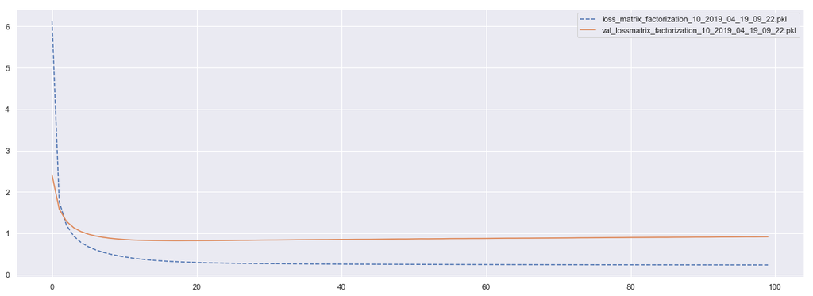

```python
histories = ['matrix_factorization_10_2019_04_19_09_22.pkl']

import pickle
plt.figure( figsize = ( 20, 7 ) )
for val in histories:
    with open(mainpath + '/histories/' + val , 'rb') as file_pi:
        thepickle = pickle.load(file_pi)
        plt.plot(thepickle["loss"],label ='loss_' + val,linestyle='--')
        plt.plot(thepickle["val_loss"],label='val_loss' + val)
plt.legend()
#plt.ylim(0, 1)

pd.DataFrame(thepickle,columns =['loss','val_loss']).transpose()
```

Тренирање на моделот со embedding_size=30, 100 епохи

```python
embedding_size = 30
user_embedding = Embedding(output_dim=embedding_size, input_dim=users.shape[0],
                           input_length=1, name='user_embedding')(user_id_input)
item_embedding = Embedding(output_dim=embedding_size, input_dim=beers.shape[0],
                           input_length=1, name='item_embedding')(item_id_input)

user_vecs = Reshape([embedding_size])(user_embedding)
item_vecs = Reshape([embedding_size])(item_embedding)

y = Dot(1, normalize=False)([user_vecs, item_vecs])

model = Model(inputs=[user_id_input, item_id_input], outputs=y)

model.compile(loss='mse',
              optimizer="adam"
             )

modname = 'matrix_factorization_30_' + mytime

history = model.fit([ratings_train["user_id"], ratings_train["beer_id"]]
                    , ratings_train["review_overall"]
                    , batch_size=64, epochs=100
                    , validation_split=0.1
                    , callbacks=[mcheck]
                    , shuffle=True)

import pickle
with open(mainpath + '\\histories\\' + modname + '.pkl' , 'wb') as file_pi:
    pickle.dump(history.history, file_pi)
```

```
Train on 1140678 samples, validate on 126742 samples
```

Тренирање на моделот со embedding_size=50, 100 епохи

```python
embedding_size = 50
user_embedding = Embedding(output_dim=embedding_size, input_dim=users.shape[0],
                           input_length=1, name='user_embedding')(user_id_input)
item_embedding = Embedding(output_dim=embedding_size, input_dim=beers.shape[0],
                           input_length=1, name='item_embedding')(item_id_input)

user_vecs = Reshape([embedding_size])(user_embedding)
item_vecs = Reshape([embedding_size])(item_embedding)

y = Dot(1, normalize=False)([user_vecs, item_vecs])

model = Model(inputs=[user_id_input, item_id_input], outputs=y)

model.compile(loss='mse',
              optimizer="adam"
             )

modname = 'matrix_factorization_50_' + mytime

history = model.fit([ratings_train["user_id"], ratings_train["beer_id"]]
                    , ratings_train["review_overall"]
                    , batch_size=64, epochs=100
                    , validation_split=0.1
                    , callbacks=[mcheck]
                    , shuffle=True)

import pickle
with open(mainpath + '\\histories\\' + modname + '.pkl' , 'wb') as file_pi:
    pickle.dump(history.history, file_pi)
```

```
Train on 1140678 samples, validate on 126742 samples
```

На следниот график, ќе прикажам ја прикажам распределбата на загубата на валидацискиот и на тестинг сетот при користење на ембединг матрици со големина 10, 30 и 50. Како што може да се види од графикот, користење на поголеми ембединг матрици не води до зголемување на перфомансите на алгоритам, напротив води до состојба на презаситување. Бидејќи и времето на тренирање за поголеми матрици е значително поголемо како што може да се заклучи од добиените резултати, ќе продолжам да работам со ембеднг матрици со големина 10.

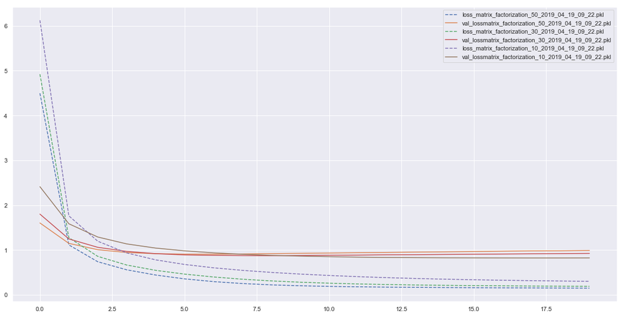

```python
histories = ['matrix_factorization_50_2019_04_19_09_22.pkl',\
             'matrix_factorization_30_2019_04_19_09_22.pkl',\
             'matrix_factorization_10_2019_04_19_09_22.pkl']

import pickle
plt.figure( figsize = ( 20, 10 ) )
for i,val in enumerate(histories):
    with open(mainpath + '/histories/' + val , 'rb') as file_pi:
        thepickle = pickle.load(file_pi)
        plt.plot(thepickle["loss"][:20],label ='loss_' + val,linestyle="--")
        plt.plot(thepickle["val_loss"][:20],label='val_loss' + val)
plt.legend()
#a= plt.ylim(0, 1)
```

### Модел со длабоко учење

Во погорниот пример со факторизација на матрици, алгоритмот ги учи ембединг матриците и го добива предвидениот резултат како производ на соодветниот ред со соодветната колона.

Наместо да се ограничуваме само на едно ниво на пресметки, може наместо множење на матриците, да имплементираме сосема различни архитектури со најразлично комбинирање на повеќе слоеви пресметки.

На пример, една можност е после генерирање на ембединг матриците, резултатот да го добиеме преку два нови слоја - concatenate кој ги подготвува податоците во соодветен формат и dense слој кој додава нелинеарност со тоа што врз податоците аплицира некоја функција за нелинеарност како sigmoid, relu, softmax итн.

На овој начин, алгоритамот може самиот да го одлучи начинот на кој ќе го добива резултатот, наспорти претходниот пристап каде што ние му кажувавме дека ќе го добива преку множење на соодветните матрици.

```python
from keras.layers import Concatenate
from keras.layers import Activation, Dense
```

```python
user_id_input = Input(shape=[1], name='user')
item_id_input = Input(shape=[1], name='item')

embedding_size = 10
user_embedding = Embedding(output_dim=embedding_size, input_dim=users.shape[0],
                           input_length=1, name='user_embedding')(user_id_input)
item_embedding = Embedding(output_dim=embedding_size, input_dim=beers.shape[0],
                           input_length=1, name='item_embedding')(item_id_input)

user_vecs = Reshape([embedding_size])(user_embedding)
item_vecs = Reshape([embedding_size])(item_embedding)

input_vecs = Concatenate()([user_vecs, item_vecs])

x = Dense(128, activation='relu')(input_vecs)
# x = Dense(128, activation='relu')(x)

y = Dense(1)(x)


model = Model(inputs=[user_id_input, item_id_input], outputs=y)
model.compile(optimizer='adam', loss='mse')
```

```python
SVG(model_to_dot(model).create(prog='dot', format='svg'))
```

[figure not shown]

```python
mainpath = 'C:\\Users\\pesovski\\Anaconda2\\envs\\ip\\beer_recommendation'
save_path = mainpath + "\\models"
mytime = time.strftime("%Y_%m_%d_%H_%M")
modname = 'deep_learning_10_' + mytime
thename = save_path + '\\' + modname + '.h5'
mcheck = ModelCheckpoint(thename  , monitor='val_loss', save_best_only=True)
```

```python
#тренирање на моделот
history = model.fit([ratings_train["user_id"], ratings_train["beer_id"]]
                    , ratings_train["review_overall"]
                    , batch_size=64, epochs=100
                    , validation_split=0.1
                    , callbacks=[mcheck]
                    , shuffle=True)

import pickle
with open(mainpath + '\\histories\\' + modname + '.pkl' , 'wb') as file_pi:
    pickle.dump(history.history, file_pi)
```

```
Train on 1140678 samples, validate on 126742 samples
```

|  | 0 | 1 | 2 | 3 | 4 | 5 | 6 | 7 | 8 | 9 | ... | 90 | 91 | 92 | 93 | 94 | 95 | 96 | 97 | 98 | 99 |
| --- | --- | --- | --- | --- | --- | --- | --- | --- | --- | --- | --- | --- | --- | --- | --- | --- | --- | --- | --- | --- | --- |
| loss | 0.355403 | 0.341661 | 0.331222 | 0.320644 | 0.310779 | 0.301638 | 0.292946 | 0.285106 | 0.278258 | 0.272217 | ... | 0.202499 | 0.202376 | 0.202149 | 0.201964 | 0.201853 | 0.201740 | 0.201519 | 0.201427 | 0.201235 | 0.201223 |
| val_loss | 0.370078 | 0.378730 | 0.365363 | 0.371283 | 0.369887 | 0.374024 | 0.375991 | 0.380794 | 0.384529 | 0.387921 | ... | 0.485218 | 0.482486 | 0.485636 | 0.490082 | 0.482229 | 0.488415 | 0.482637 | 0.486342 | 0.493743 | 0.493556 |

2 rows × 100 columns

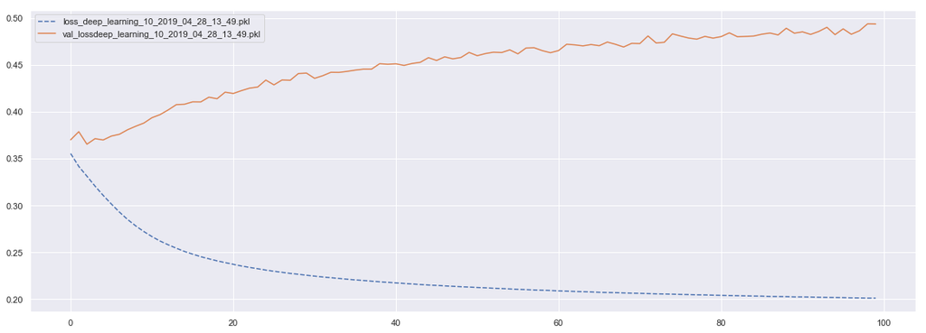

```python
histories = ['deep_learning_10_2019_04_28_13_49.pkl']

import pickle
plt.figure( figsize = ( 20, 7 ) )
for val in histories:
    with open(mainpath + '/histories/' + val , 'rb') as file_pi:
        thepickle = pickle.load(file_pi)
        plt.plot(thepickle["loss"],label ='loss_' + val,linestyle='--')
        plt.plot(thepickle["val_loss"],label='val_loss' + val)
plt.legend()
#plt.ylim(0, 1)

pd.DataFrame(thepickle,columns =['loss','val_loss']).transpose()
```

Иако не излега интуитивно на прв поглед, овие резултати се далеку подобри од оние добиени со моделот без длабоко учење. На следниот график се прикажани заедно загубите на моделот со matrix factorization и на моделот со длабоко учење. Загубата на тест сетот е преставена со полни линии и тоа со црвената линија при користење факторизација на матрици, а со портокалова при користење длабоко учење. Може да се заклучи дека во текот на сите епохи загубата при користење на длабоко учење иако постојано се зголемува, повторно е прилично помала отколку онаа кога не се користи длабоко учење. Најмала вредност на загубата при користење на пристапот без длабоко учење е 0.822 во 18тата епоха, додека најмала вредност при користење на длабоко учење изнесува 0.365 и се достигнува во втората епоха. Ова значи дека моделот со длабоко учење ќе дава повеќе од двојно поточни резултати и неговото тренирање може да заврши многу порано. Загубата на валидацискиот сет исто така конвергира кон нејзината минимална вредност многу рано, односо уште од првата епоха е блиску до својот минимум за разлика од претходниот случај каде загубата на валдацискиот сет почнува од многу голема вредност и конвергира конј нејзиниот минимум после дваесеттина епохи.

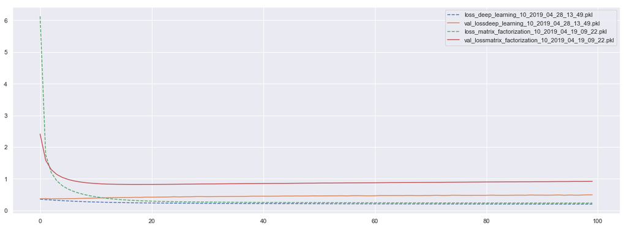

```python
histories = ['deep_learning_10_2019_04_28_13_49.pkl', 'matrix_factorization_10_2019_04_19_09_22.pkl']

import pickle
plt.figure( figsize = ( 20, 7 ) )
for i,val in enumerate(histories):
    with open(mainpath + '/histories/' + val , 'rb') as file_pi:
        thepickle = pickle.load(file_pi)
        plt.plot(thepickle["loss"][:100],label ='loss_' + val,linestyle="--")
        plt.plot(thepickle["val_loss"][:100],label='val_loss' + val)
plt.legend()
```

## Генерирање на препораки

Препораките што ќе ги генерирам ќе бидат базирани на колаборативни алгоритми и тоа ќе генерираат препораки врз база на соседство на корисници и врз база на соседство на пива.

После тоа ќе го направам истото за корисници, т.е. за случајно избран корисник алгоритамот ќе треба да ги врати тројцата најслични корисници за да ги видиме пивата што тие ги имаат оценето и да донесам заклучок дали се добри препораки за појдовниот корисник.

Ќе генерирам препораки за следните 5 пива:

[output not shown]

Овие пива не се случајно избрани. Првите две се меѓу најмногу рангираните пива, вторите две се меѓу најдобро рангираните пива, а последното е пиво со само една оценка. Идејата е да видиме како се однесува алгоритамот во разни ситуации.

```python
firstbeer = beers_data.loc[beers_data['beer_beerid'] == 2093].head(1) #90 Minute IPA
secondbeer = beers_data.loc[beers_data['beer_beerid'] == 1904].head(1) #Sierra Nevada Celebration Ale
thirdbeer = beers_data.loc[beers_data['beer_beerid'] == 1545].head(1) #Trappist Westvleteren 12
fourthbeer = beers_data.loc[beers_data['beer_beerid'] == 34420].head(1) #The Abyss
fifthbeer = beers_data.loc[beers_data['beer_beerid'] == 47969].head(1) #Sausa Pils

sample_data = pd.concat([firstbeer,secondbeer,thirdbeer,fourthbeer,fifthbeer])
mybeers = pd.DataFrame(data=sample_data)
mybeers
```

|  | brewery_name | beer_style | beer_name | beer_beerid | beer_abv | review_appearance | review_aroma | review_palate | review_taste | review_overall | review_average | review_average_rounded | review_profilename | review_time | user_id | beer_id |
| --- | --- | --- | --- | --- | --- | --- | --- | --- | --- | --- | --- | --- | --- | --- | --- | --- |
| 1166284 | Dogfish Head Brewery | American Double / Imperial IPA | 90 Minute IPA | 2093 | 9.0 | 4.5 | 4.5 | 4.5 | 4.5 | 4.0 | 4.4 | 4.5 | DmanGTR | 2010-02-21 17:59:24 | 1756 | 48206 |
| 76393 | Sierra Nevada Brewing Co. | American IPA | Sierra Nevada Celebration Ale | 1904 | 6.8 | 4.0 | 4.0 | 4.0 | 4.0 | 4.5 | 4.1 | 4.0 | jaycount | 2010-11-24 01:31:57 | 7068 | 3558 |
| 1479675 | Brouwerij Westvleteren (Sint-Sixtusabdij van Westvleteren) | Quadrupel (Quad) | Trappist Westvleteren 12 | 1545 | 10.2 | 5.0 | 5.0 | 5.0 | 5.0 | 5.0 | 5.0 | 5.0 | lwhcchh | 2011-09-19 00:07:18 | 32666 | 61884 |
| 1437220 | Deschutes Brewery | American Double / Imperial Stout | The Abyss | 34420 | 11.0 | 4.0 | 3.5 | 3.5 | 4.0 | 3.5 | 3.7 | 3.5 | fartingdog | 2008-01-24 03:19:28 | 6266 | 60447 |
| 3 | Vecchio Birraio | German Pilsener | Sausa Pils | 47969 | 5.0 | 3.5 | 3.0 | 2.5 | 3.0 | 3.0 | 3.0 | 3.0 | stcules | 2009-02-15 19:12:25 | 0 | 3 |

За да можат моделите да учат, во некој од погорните чекори морав да ги ремапирам пивата и корисниците да имаат уникатни id колони од 0 до бројот на уникатни пива/корисници соодветно. Поради тоа, моделот сега за дадено пиво ќе ни врати само id-ја на нему сличните пива (исто и за корисници) па ни треба мапирање во обратен редослед. За анализа на генерираните препораки доволни се името, стилот и промилите алкохол во пивото, како и пивницата што го произведува за да видиме дали случајно алгоритамот настојува да препорачува пива од иста пивница.

```python
beersdictionary = {row[1]['beer_id']:[row[1]['beer_name'],\
                                      row[1]['beer_style'],\
                                      row[1]['beer_abv'],\
                                      row[1]['brewery_name']]\
                   for row in beers_data.iterrows()}
first3pairs = {k: beersdictionary[k] for k in list(beersdictionary)[:3]}
first3pairs
```

```
{0: ['Sausa Weizen', 'Hefeweizen', 5.0, 'Vecchio Birraio'],
 1: ['Red Moon', 'English Strong Ale', 6.2, 'Vecchio Birraio'],
 2: ['Black Horse Black Beer',
  'Foreign / Export Stout',
  6.5,
  'Vecchio Birraio']}
```

Фунцкиите за пресметување за сличност меѓу 2 вектори. Подолу се дадени функциите за пресметување сличност и како косинус меѓу два агли и како Еуклидово растојание меѓу 2 вектори. Во примерите подолу ќе биде користен првиот пристап со пресметување на косинус.

```python
EPSILON = 1e-07

def cosine(x, y):
    dot_pdt = np.dot(x, y.T)
    norms = np.linalg.norm(x) * np.linalg.norm(y)
    return dot_pdt / (norms + EPSILON)

def cosine_similarities(x,embeddings):
    dot_pdt = np.dot(embeddings, x)
    norms = np.linalg.norm(x) * np.linalg.norm(embeddings,axis = 1)
    return dot_pdt / (norms + EPSILON)

# Computes euclidean distances between x and all item embeddings
def euclidean_distances(x,embeddings):
    return np.linalg.norm(embeddings - x,axis=1)

# Computes top_n most similar items to an idx
def most_similar(idx, embeddings, dictionary, top_n=10, euclidian=False, entity='beer'):
    if euclidian:
        # eucliedian distance between idx and the rest
        distance = euclidean_distances(embeddings[int(idx)],embeddings)
        order = (distance).argsort()
        order= [x for x in order if x != idx]
        order= order[:top_n]
        return list(zip([dictionary[x] for x in order], distance[order]))
    else:
        # cosine similarity between idx and the rest
        distance = cosine_similarities(embeddings[int(idx)],embeddings)
        order = (-distance).argsort()
        order= [x for x in order if x != idx]
        order= order[:top_n]
        if entity == 'beer':
            return list(zip([dictionary[x][0] for x in order],\
                        distance[order],\
                        [dictionary[x][1] for x in order],\
                        [dictionary[x][2] for x in order],\
                        [dictionary[x][3] for x in order]\
                       ))
        else:
            return list(zip([dictionary[x] for x in order], distance[order]))
```

### Користејќи го моделот со matrix factorization

Вчитување на тренираниот модел и земање на генерираните ембединзи. Нивниот формат е 33375x10 на ембедингот за корисниците и 65915x10 на ембединг за пивата т.е. онолку редови колку што има уникатни корисници/пива и 10 колони бидејќи така избрав поради резултатите при тренирањето на моделот со различни големини како што дискутирав погоре.

```python
from keras.models import load_model
load_path = "C:\\Users\\pesovski\\Anaconda2\\envs\\ip\\beer_recommendation\\models\\"
model = load_model(load_path+'matrix_factorization_10_2019_04_19_09_22.h5')
weights = model.get_weights()
user_embeddings_matrix_factorization_model = weights[0]
item_embeddings_matrix_factorization_model = weights[1]
print([w.shape for w in weights])
```

```
[(33375, 10), (65915, 10)]
```

За секое од 5те пива, најди ги 10те најблиски соседи.

```python
from IPython.core import display as ICD
similarbeers = []
for i,row in enumerate(mybeers.iterrows()):
    row = row[1]

    similars = pd.DataFrame(most_similar(row["beer_id"],
                                         item_embeddings_matrix_factorization_model,
                                         beersdictionary,
                                         top_n=10,
                                         euclidian= False))
    similars.columns = ['Similar to: ' + row["beer_name"], \
                        'Cosine score: ', \
                        'Style: ' + row["beer_style"], \
                        'Alcohol: ' + str(row["beer_abv"]) + '%', \
                        'Brewery: ' + row["brewery_name"]]
    similarbeers.append(similars)

    final = pd.concat(similarbeers,axis=1)
    ICD.display(final)
    similarbeers=[]
similarbeers
```

|  | Similar to: 90 Minute IPA | Cosine score: | Style: American Double / Imperial IPA | Alcohol: 9.0% | Brewery: Dogfish Head Brewery |
| --- | --- | --- | --- | --- | --- |
| 0 | Rock Bottom Chai Porter | 0.970650 | American Porter | NaN | Rock Bottom Restaurant & Brewery |
| 1 | Smuttynose Imperial Stout (Big Beer Series) | 0.967442 | Russian Imperial Stout | 9.8 | Smuttynose Brewing Company |
| 2 | Dark Lord Imperial Stout | 0.967261 | Russian Imperial Stout | 15.0 | Three Floyds Brewing Co. & Brewpub |
| 3 | Maharaja | 0.956465 | American Double / Imperial IPA | 10.3 | Avery Brewing Company |
| 4 | Storm King Stout | 0.955831 | Russian Imperial Stout | 9.1 | Victory Brewing Company |
| 5 | Olde GnarlyWine | 0.953599 | American Barleywine | 10.6 | Lagunitas Brewing Company |
| 6 | Holidale | 0.953246 | American Barleywine | 9.5 | Berkshire Brewing Company Inc. |
| 7 | Oak Aged Unearthly (Imperial India Pale Ale) | 0.949212 | American Double / Imperial IPA | 11.0 | Southern Tier Brewing Company |
| 8 | Andelot Cuvee Angelique | 0.949056 | Dubbel | 7.0 | De Proefbrouwerij (bvba Andelot) |
| 9 | Double Enghien Brune | 0.948647 | Belgian Strong Dark Ale | 8.0 | Brasserie de Silly S.A. |

|  | Similar to: Sierra Nevada Celebration Ale | Cosine score: | Style: American IPA | Alcohol: 6.8% | Brewery: Sierra Nevada Brewing Co. |
| --- | --- | --- | --- | --- | --- |
| 0 | Ruedrich's Red Seal Ale | 0.981567 | American Amber / Red Ale | 5.5 | North Coast Brewing Co. |
| 1 | Great Lakes Burning River Pale Ale | 0.972041 | American Pale Ale (APA) | 6.0 | Great Lakes Brewing Company |
| 2 | Sierra Nevada Stout | 0.970589 | American Stout | 5.8 | Sierra Nevada Brewing Co. |
| 3 | Anchor Liberty Ale | 0.970580 | American Pale Ale (APA) | 6.0 | Anchor Brewing Company |
| 4 | Braumeister Harvest Pils | 0.969796 | German Pilsener | 6.1 | Victory Brewing Company |
| 5 | New World Porter | 0.969283 | American Porter | 6.7 | Avery Brewing Company |
| 6 | Adnams Broadside Strong Original | 0.966612 | English Strong Ale | 6.3 | Adnams plc, Sole Bay Brewery |
| 7 | Hoptical Illusion | 0.964613 | American IPA | 6.8 | Blue Point Brewing Company |
| 8 | Cadillac Mountain Stout | 0.963999 | American Stout | 6.7 | Bar Harbor Brewing Company |
| 9 | Drake's Amber Ale | 0.963645 | Extra Special / Strong Bitter (ESB) | 5.9 | Drake's Brewing Co. |

|  | Similar to: Trappist Westvleteren 12 | Cosine score: | Style: Quadrupel (Quad) | Alcohol: 10.2% | Brewery: Brouwerij Westvleteren (Sint-Sixtusabdij van Westvleteren) |
| --- | --- | --- | --- | --- | --- |
| 0 | Indian Brown Ale | 0.995522 | American Brown Ale | 7.20 | Dogfish Head Brewery |
| 1 | Big Bourbon Series Curse The Goat Dopplebock | 0.994395 | Doppelbock | 10.00 | Shoreline Brewery And Restaurant |
| 2 | Trois Pistoles | 0.994363 | Belgian Strong Dark Ale | 9.00 | Unibroue |
| 3 | Founders CBS Imperial Stout | 0.994172 | American Double / Imperial Stout | 10.60 | Founders Brewing Company |
| 4 | Black Horse Ale | 0.994096 | American Black Ale | 7.40 | Horseheads Brewing Inc. |
| 5 | Mørke - Pumpernickel Porter | 0.993983 | Baltic Porter | 7.50 | Beer Here |
| 6 | Stone 06.06.06 Vertical Epic Ale | 0.993834 | Belgian Strong Dark Ale | 8.66 | Stone Brewing Co. |
| 7 | Amarillo Red Ale | 0.993123 | American Amber / Red Ale | 6.20 | Barley John's Brew Pub |
| 8 | Gouden Carolus Classic | 0.992978 | Belgian Strong Dark Ale | 8.50 | Brouwerij Het Anker |
| 9 | PK Nice | 0.992823 | American Malt Liquor | 8.30 | Ninkasi Brewing Company |

|  | Similar to: The Abyss | Cosine score: | Style: American Double / Imperial Stout | Alcohol: 11.0% | Brewery: Deschutes Brewery |
| --- | --- | --- | --- | --- | --- |
| 0 | Einbecker Brauherren Non-Alcoholic | 0.989381 | Low Alcohol Beer | 0.5 | Einbecker Brauhaus AG |
| 1 | Pliny The Younger | 0.987952 | American Double / Imperial IPA | 11.0 | Russian River Brewing Company |
| 2 | Founders Backwoods Bastard | 0.987111 | Scotch Ale / Wee Heavy | 10.2 | Founders Brewing Company |
| 3 | Saison Farmhouse Ale | 0.986767 | Saison / Farmhouse Ale | 4.9 | Bluegrass Brewing Co. - East St. Matthew's |
| 4 | L'Armûre | 0.983583 | Fruit / Vegetable Beer | 7.0 | Le Grimoire |
| 5 | Papier | 0.982755 | Old Ale | 14.5 | The Bruery |
| 6 | Founders Double Trouble | 0.982698 | American Double / Imperial IPA | 9.4 | Founders Brewing Company |
| 7 | Wet | 0.982693 | American IPA | 7.5 | Surly Brewing Company |
| 8 | Mike | 0.982554 | Dubbel | 7.6 | Weyerbacher Brewing Co. |
| 9 | Ice Apparition | 0.981953 | American Double / Imperial Stout | 12.0 | Jackie O's Pub & Brewery |

|  | Similar to: Sausa Pils | Cosine score: | Style: German Pilsener | Alcohol: 5.0% | Brewery: Vecchio Birraio |
| --- | --- | --- | --- | --- | --- |
| 0 | Vetter Helles | 0.998916 | Munich Helles Lager | NaN | Vetter Alt Heidelberger Brauhaus |
| 1 | Calypso | 0.998809 | American Pale Ale (APA) | 5.2 | Birrificio Valcavallina |
| 2 | Castagnasca | 0.998678 | Euro Pale Lager | 6.0 | Fabbrica Birra Busalla |
| 3 | Breizh Blanche | 0.998626 | Witbier | 6.0 | Brasserie Warenghem |
| 4 | Golden Lance | 0.998594 | English Pale Ale | 4.0 | Keltek Brewing Company Ltd |
| 5 | Black Horse Black Beer | 0.998539 | Foreign / Export Stout | 6.5 | Vecchio Birraio |
| 6 | Irish Red Ale | 0.998418 | Irish Red Ale | 4.5 | Redoak Boutique Beer Café |
| 7 | Ciechan Porter | 0.998405 | Baltic Porter | 9.0 | Browar Ciechan |
| 8 | Freiherr Von Zech Hefe-Weizen | 0.998317 | Hefeweizen | 5.1 | Brauerei Josef Schimpfle |
| 9 | Hirsch Gold | 0.998295 | Dortmunder / Export Lager | 5.2 | Hirschbrauerei GmbH & Co. KG |

```
[]
```

Поради природата на податоците со кои работам како и нивното потекло, малку е тешко да се видат директни корелации помеѓу било кое од пивата за кое се бараат препораки и генерираните препораки.

- **90 Minute IPA**

  Како најмногу оценувано пиво во податочниот сет со над 3000 оценки, би очекувале и пивата слични на него што ги генерира алгоритамот да имаат голем број на оценки. Ова и се случува. Со исклучок на првото (најсличното) пиво, остантите пива имаат стотици и илјадници оценки секое. Јасно видлива причина зошто Rock Bottom Chai Porter со само 2 оценки е најслично пиво (има најголема вредност за косинусот меѓу векторите) не можам да извлечам. Интересна е распределбата на промилите алкохол. 90 Minute IPA, спаѓа во групата на империјални (дупли) IPA пива што значи дека е доста појако од нормално пиво и има 9 промили алкохол. Како што може да се види од генерираните резултати, сите 10 слични пива имаат висока концентрација на алкохол. Ова веројатно значи, дека луѓето што оцениле добро вакво пиво уживаат во јаки пива со посилен вкус, па можеме да заклучиме дека препораките се добри и дека моделот добро тренирал.
- **Sierra Nevada Celebration Ale**

  И овде важат статистиките за бројот на оценки на сличните пива како погоре, т.е. сите пива имаат значителен број на оценки. Истиот заклучок важи и за распределата на промилите на алкохол. Пивото во прашање не е империјално туку обично IPA пиво со пониска вредност на промили алкохол, па и сличните пива го следат истиот тренд. Интересно е и што е препорачано уште едно пиво од истата пивница и знаејќи дека Sierra Nevada Brewing Co. е меѓу најпознатите пивници во САД, ова личи како добра препорака бидејќи корисник што добро оценил пиво од оваа пивара веројатно би сакал да проба уште некое.
- **Trappist Westvleteren 12**

  Ова е најдобро рангирано пиво во податочниот сет гледајќи според нормализираните средни оценки. Нему сличните пива, од друга страна не се толку добро рангирани. Две од пивата се со оценки 0.66 и 0.31, а останатите се во опсегот од 3 до 4. Ова е изненадувачки имајќи го предвид фактот дека моделот учеше директно од средните оценките на пивата. Препораките повторно го следат трендот да бидат блиску по вредност на промили на алкохол со појдовното пиво и се добива илузија дека моделот учел да препорачува пива слични по оваа вредност што не е случај.
- **The Abyss**

  Ова е уште едно од најдобро рангираните пива. И овде повторно истото не се одразува кај сличните пива. Само две од десетте се со нормализирана средна оценка поголема од 4. Овде е интересно што за првпат промилите не се директно корелирани меѓу појдовното пиво и препораките. Иако The Abyss е империјално пиво со многу промили алкохол, во препораките може да се сретне и едно безалкохолно пиво и уште две послаби пива со овошен вкус.
- **Sausa Pils**

  Ова е пивото со само една оценка. Препораките овде исто се пива со мал број оценки и тоа 6 од 10те имаат само по 1 оценка, а најмногу оценуваното пиво меѓу нив има само 7 оценки. Повторно сите пива се блиску ако се споредат според промили алкохол. Препораките овде изгледаат најочигледни. Sausa Pils е германски пилснер произведен во Италија, а во сличните пива доминираат исто така германски лесни пива. Освен Irish Red Ale кое е произведено во Сиднеј, сите останати пива се произведени во Европа, што беше реткост во претходните примери каде доминираа американски пива. Овој податок можеби е најдобар показател дека алгоритмот со matrix factorization генерира соодветени препораки и е добро истрениран.

Пред да направам генерирање на препораки со моделот добиен со длабоко учење, ќе ги најдам најсличните корисници на даден корисник за да видам дали таму може да се најдат некои интересни корелации. После барање на карактеристични корисници кои оценуваат само одредени видови пиво за да можам полесно да ги интерпретирам препораките, решив да барам препораки за следните 4 корисници.

[output not shown]

За секој од нив ќе побарам алгоритамот да ми ги врати 3те нему најслични корисници.

```python
data=np.array([['ylivakkuri'], ['yzerman'], ['zappuh'], ['zuker']])
currentuser = pd.DataFrame(data=data,columns = ['review_profilename'])

currentuser["user_id"]=currentuser["review_profilename"].map(inverse_user_map)

pd.set_option('display.max_colwidth', -1)
currentuser
```

|  | review_profilename | user_id |
| --- | --- | --- |
| 0 | ylivakkuri | 17135 |
| 1 | yzerman | 16644 |
| 2 | zappuh | 6629 |
| 3 | zuker | 8038 |

Пивата што ги има оценето секој од нив подредени според корисничко име се:

```python
pd.concat([(beers_data.loc[ beers_data['review_profilename'] == 'ylivakkuri']),
           (beers_data.loc[ beers_data['review_profilename'] == 'yzerman']),
           (beers_data.loc[ beers_data['review_profilename'] == 'zappuh']),
           (beers_data.loc[ beers_data['review_profilename'] == 'zuker'])]) \
[['review_profilename', 'brewery_name', 'beer_name', 'beer_style', 'beer_abv', 'review_average']]
```

|  | review_profilename | brewery_name | beer_name | beer_style | beer_abv | review_average |
| --- | --- | --- | --- | --- | --- | --- |
| 256123 | ylivakkuri | Micro-Brasserie Breughel | Grand Cru | Belgian Strong Pale Ale | 11.0 | 4.8 |
| 433867 | ylivakkuri | Brasseurs R.J. | Cap Espoir | Belgian Pale Ale | 5.0 | 2.4 |
| 1385585 | ylivakkuri | Multi-Brasses | La Gladiamort | Belgian Strong Pale Ale | 9.0 | 2.0 |
| 240459 | yzerman | Brouwerij Van Steenberge N.V. | Piraat Ale | Belgian IPA | 10.5 | 4.0 |
| 969795 | yzerman | Brouwerij Duvel Moortgat NV | Duvel | Belgian Strong Pale Ale | 8.5 | 5.0 |
| 975627 | yzerman | Abbaye de Leffe S.A. | Leffe Blonde | Belgian Pale Ale | 6.6 | 3.8 |
| 34445 | zappuh | Founders Brewing Company | Founders KBS (Kentucky Breakfast Stout) | American Double / Imperial Stout | 11.2 | 4.1 |
| 339441 | zappuh | Brasserie de Rochefort | Trappistes Rochefort 8 | Dubbel | 9.2 | 4.0 |
| 473278 | zappuh | Weyerbacher Brewing Co. | Fifteen | American Double / Imperial Stout | 10.8 | 4.3 |
| 932985 | zappuh | Bell's Brewery, Inc. | Bell's Hopslam Ale | American Double / Imperial IPA | 10.0 | 4.5 |
| 46776 | zuker | Plzensky Prazdroj, a. s. | Pilsner Urquell | Czech Pilsener | 4.4 | 3.6 |
| 245758 | zuker | Karlova&#267;ka Pivovara | Karlovacko | Czech Pilsener | 5.0 | 3.3 |
| 1085328 | zuker | Northern Breweries Ltd. | Red Maple Premium Lager | American Amber / Red Lager | 5.2 | 3.2 |
| 1085347 | zuker | Northern Breweries Ltd. | Northern Superior | American Adjunct Lager | 5.0 | 2.9 |

```python
similarusers = []
for i,row in enumerate(currentuser.iterrows()):
    row = row[1]

    similars = pd.DataFrame(most_similar(row["user_id"],
                                         user_embeddings_matrix_factorization_model,
                                         user_map,
                                         top_n=3,
                                         euclidian= False,
                                         entity='user'))
    similars.columns = ['Similar to: ' + row["review_profilename"],'Cosine Score' ]
    similarusers.append(similars)

    final = pd.concat(similarusers,axis=1)
    ICD.display(final)
    similarusers=[]
similarusers
```

|  | Similar to: ylivakkuri | Cosine Score |
| --- | --- | --- |
| 0 | danielpollard | 0.999614 |
| 1 | jimmy123 | 0.999508 |
| 2 | NordeastBrewer77 | 0.999481 |

|  | Similar to: yzerman | Cosine Score |
| --- | --- | --- |
| 0 | wiscokid920 | 0.999830 |
| 1 | belgianalien | 0.999816 |
| 2 | moesizlacks | 0.999804 |

|  | Similar to: zappuh | Cosine Score |
| --- | --- | --- |
| 0 | jkempe11 | 0.999856 |
| 1 | thedon10 | 0.999556 |
| 2 | Rangermonk | 0.999396 |

|  | Similar to: zuker | Cosine Score |
| --- | --- | --- |
| 0 | mtloconto | 0.998792 |
| 1 | Drewer757 | 0.998749 |
| 2 | Madrigae | 0.998688 |

```
[]
```

Оценетите пива на сличните корисници на ylivakkuri:

```python
beers_data.loc[ (beers_data['review_profilename'] == 'danielpollard') | \
                (beers_data['review_profilename'] == 'jimmy123') | \
                (beers_data['review_profilename'] == 'NordeastBrewer77')
              ] [['review_profilename', 'brewery_name', 'beer_name', 'beer_style', 'beer_abv', 'review_average']]
```

|  | review_profilename | brewery_name | beer_name | beer_style | beer_abv | review_average |
| --- | --- | --- | --- | --- | --- | --- |
| 109230 | jimmy123 | Creemore Springs Brewery Limited | Creemore Springs Premium Lager | American Amber / Red Lager | 5.0 | 4.6 |
| 520116 | NordeastBrewer77 | Samuel Smith Old Brewery (Tadcaster) | Samuel Smith's India Ale | English India Pale Ale (IPA) | 5.0 | 3.8 |
| 779573 | NordeastBrewer77 | Surly Brewing Company | Abrasive Ale | American Double / Imperial IPA | 9.0 | 4.6 |
| 919203 | NordeastBrewer77 | Wychwood Brewery Company Ltd | King Goblin | English Strong Ale | 6.6 | 3.4 |
| 1094927 | danielpollard | Heater Allen Brewing | Mediator | Doppelbock | 7.0 | 3.2 |
| 1098887 | NordeastBrewer77 | Left Hand Brewing Company | 400 Pound Monkey | English India Pale Ale (IPA) | 6.7 | 3.7 |
| 1100383 | NordeastBrewer77 | Left Hand Brewing Company | Sawtooth Ale | Extra Special / Strong Bitter (ESB) | 5.3 | 3.9 |
| 1148419 | NordeastBrewer77 | Fuller Smith & Turner PLC | Fuller's ESB | Extra Special / Strong Bitter (ESB) | 5.9 | 4.2 |
| 1319449 | NordeastBrewer77 | Anchor Brewing Company | Anchor Liberty Ale | American Pale Ale (APA) | 6.0 | 3.5 |
| 1411547 | NordeastBrewer77 | Wells & Young's Ltd | Wells Bombardier (English Premium Bitter) | Extra Special / Strong Bitter (ESB) | 5.2 | 4.2 |
| 1508579 | NordeastBrewer77 | Central Waters Brewing Company | Shine On | American Amber / Red Ale | NaN | 3.0 |
| 1509670 | NordeastBrewer77 | Central Waters Brewing Company | Glacial Trail IPA | American IPA | 5.5 | 3.8 |

Овде гледано само поред стил на пиво што и беше идејата за овој корисник, нема директни корелации меѓу пивата.

Оценетите пива на сличните корисници на yzerman:

```python
beers_data.loc[ (beers_data['review_profilename'] == 'wiscokid920') | \
                (beers_data['review_profilename'] == 'belgianalien') | \
                (beers_data['review_profilename'] == 'moesizlacks')
              ] [['review_profilename', 'brewery_name', 'beer_name', 'beer_style', 'beer_abv', 'review_average']]
```

|  | review_profilename | brewery_name | beer_name | beer_style | beer_abv | review_average |
| --- | --- | --- | --- | --- | --- | --- |
| 21153 | moesizlacks | Founders Brewing Company | Founders Harvest Ale | American IPA | 6.5 | 4.6 |
| 33953 | wiscokid920 | Founders Brewing Company | Founders KBS (Kentucky Breakfast Stout) | American Double / Imperial Stout | 11.2 | 5.0 |
| 132091 | moesizlacks | Port Brewing Company / Pizza Port | Ne Goeien Saison | Saison / Farmhouse Ale | 5.5 | 5.0 |
| 206945 | wiscokid920 | New Belgium Brewing | Trippel Belgian Style Ale | Tripel | 7.8 | 3.8 |
| 773154 | wiscokid920 | Brewery Ommegang | Hennepin (Farmhouse Saison) | Saison / Farmhouse Ale | 7.7 | 4.3 |
| 932994 | wiscokid920 | Bell's Brewery, Inc. | Bell's Hopslam Ale | American Double / Imperial IPA | 10.0 | 4.5 |
| 1280859 | wiscokid920 | New Holland Brewing Company | New Holland The Poet | Oatmeal Stout | 5.2 | 4.1 |
| 1383830 | belgianalien | Brouwerij De Musketiers | Troubadour Blond Ale | Belgian Pale Ale | 6.5 | 4.7 |
| 1584287 | belgianalien | Brouwerij Corsendonk | Corsendonk Agnus / Abbey Pale Ale | Tripel | 7.5 | 4.1 |

Кај овој корисник, 3 од 9те пива на нему слични корисници се белгиски, што од една страна не е доволно за да се изведат заклучоци дека постои корелација, но од друга страна од вкупно повеќе од 60 000 пива да му се предложат баш 3 белгиски може да се третира како успех на алгоритамот.

Оценетите пива на сличните корисници на zappuh:

```python
beers_data.loc[ (beers_data['review_profilename'] == 'jkempe11') | \
                (beers_data['review_profilename'] == 'thedon10') | \
                (beers_data['review_profilename'] == 'Rangermonk')
              ] [['review_profilename', 'brewery_name', 'beer_name', 'beer_style', 'beer_abv', 'review_average']]
```

|  | review_profilename | brewery_name | beer_name | beer_style | beer_abv | review_average |
| --- | --- | --- | --- | --- | --- | --- |
| 70066 | jkempe11 | Sierra Nevada Brewing Co. | Sierra Nevada Kellerweis Hefeweizen | Hefeweizen | 4.8 | 4.7 |
| 131122 | thedon10 | Port Brewing Company / Pizza Port | High Tide Fresh Hop IPA | American IPA | 6.5 | 4.3 |
| 137015 | thedon10 | Port Brewing Company / Pizza Port | Wipeout I.P.A. | American IPA | 7.0 | 4.4 |
| 156047 | Rangermonk | Southern Tier Brewing Company | Iniquity (Imperial Black Ale) | American Black Ale | 9.0 | 4.5 |
| 192978 | thedon10 | Green Flash Brewing Co. | Green Flash Imperial India Pale Ale | American Double / Imperial IPA | 9.4 | 3.4 |
| 263174 | jkempe11 | Vetter Alt Heidelberger Brauhaus Neuenheim | Märzen | Märzen / Oktoberfest | NaN | 4.7 |
| 615624 | thedon10 | Ballast Point Brewing Company | Sculpin India Pale Ale | American IPA | 7.0 | 4.0 |
| 870073 | jkempe11 | Stone Brewing Co. | Arrogant Bastard Ale | American Strong Ale | 7.2 | 4.5 |
| 879028 | Rangermonk | Stone Brewing Co. | Stone IPA (India Pale Ale) | American IPA | 6.9 | 4.2 |
| 973828 | Rangermonk | Diamond Knot Brewery | Industrial IPA | American Double / Imperial IPA | 7.9 | 4.3 |
| 1122455 | Rangermonk | Smuttynose Brewing Company | Smuttynose Gravitation (Big Beer Series) | Quadrupel (Quad) | 12.0 | 4.1 |
| 1172156 | jkempe11 | Dogfish Head Brewery | 60 Minute IPA | American IPA | 6.0 | 4.6 |
| 1186017 | thedon10 | Dogfish Head Brewery | Punkin Ale | Pumpkin Ale | 7.0 | 4.3 |
| 1480703 | jkempe11 | Paulaner Brauerei GmbH & Co. KG | Paulaner Original Münchner | Munich Helles Lager | 4.9 | 4.2 |

За разлика од претходно, кога барав сличност меѓу пива и каде изгледаше дека сличните пива со секое од таргетираните се многу блиску по вредност на промили алкохол, истото не може да се преслика при барање на слични корисници. Кај тројцата слични корисници на zappuh кој оценува само јаки пива, доминираат пива со помалку алкохол, па и ваквата корелација не може да се докаже кај избраните корисници.

Оценетите пива на сличните корисници на zuker:

```python
beers_data.loc[ (beers_data['review_profilename'] == 'mtloconto') | \
                (beers_data['review_profilename'] == 'Drewer757') | \
                (beers_data['review_profilename'] == 'Madrigae')
              ] [['review_profilename', 'brewery_name', 'beer_name', 'beer_style', 'beer_abv', 'review_average']]
```

|  | review_profilename | brewery_name | beer_name | beer_style | beer_abv | review_average |
| --- | --- | --- | --- | --- | --- | --- |
| 170228 | mtloconto | Blue Hills Brewery | Blue Hills India Pale Ale | American IPA | 6.6 | 2.9 |
| 212000 | Madrigae | Lunar Brewing | Kosmonaut Hooch | Russian Imperial Stout | 12.0 | 4.7 |
| 277671 | mtloconto | Wormtown Brewing Co. | Tennessee Tat's | American Double / Imperial Stout | 9.1 | 5.0 |
| 608372 | Madrigae | Cosmos Brewery (Thai Beverage Plc.) | Chang Beer (Export) | American Adjunct Lager | 5.0 | 4.3 |
| 945631 | Madrigae | Bell's Brewery, Inc. | Bell's Lager Of The Lakes | American Pale Lager | 4.5 | 4.8 |
| 1238611 | Drewer757 | Twisted Pine Brewing Company | Torker Double IPA | American Double / Imperial IPA | 10.0 | 4.4 |
| 1333793 | Madrigae | Three Floyds Brewing Co. & Brewpub | Apocalypse Cow | American Double / Imperial IPA | 11.0 | 2.1 |
| 1337827 | Drewer757 | Three Floyds Brewing Co. & Brewpub | Dark Lord Imperial Stout | Russian Imperial Stout | 15.0 | 4.6 |
| 1417422 | Madrigae | Shipyard Brewing Co. | Old Thumper ESA | Extra Special / Strong Bitter (ESB) | 5.9 | 4.4 |
| 1565406 | Drewer757 | Birdsview Brewing Company | Scraps | American Amber / Red Ale | NaN | 4.2 |

Кај корисниците слични на zucker кој сака чешки лагер пива, не може да се најде ниту едно (барем) европско пиво, а иако сака лагер (послаби) пива, неговите соседи обично оценуваат појаки пива.

Од овие 4 примери, не може да се извлече директна корелација зошто генерираните корисници се слични на таргетираните. Пивата што ги имаат оценето не се совпаѓаат по ниту една видлива карактеристика. Единствена видлива корелација може да биде бројот на оценети пива. Првите двајца од таргетираните корисници имаат по 3 оценки, додека вторите двајца имаат по 4. И нивните соседи во просек имаат оставено мал број на оценки, па ова можеби е еден од факторите. Ќе видам дали некакви заклучоци може да се извлечат од препораките кои ќе ги генерира моделот трениран со длабоко учење.

### Користејќи го моделот со длабоко учење

Вчитување на тренираниот модел и земање на генерираните ембединзи. Освен двете ембединг матрици кои се од ист формат како претходно, сега има нови слоеви кои воведуваа нелинеарност во распределбата на оценки за да може подобро да се мапира природното однесување на корисниците.

```python
# the embeddings are the first layer weights
from keras.models import load_model
load_path = "C:\\Users\\pesovski\\Anaconda2\\envs\\ip\\beer_recommendation\\models\\"
model = load_model(load_path+'deep_learning_10_2019_04_28_13_49.h5')
weights = model.get_weights()
user_embeddings_deep_learning_model = weights[0]
item_embeddings_deep_learning_model = weights[1]
print("weights shapes",[w.shape for w in weights])
```

```
weights shapes [(33375, 10), (65915, 10), (20, 128), (128,), (128, 1), (1,)]
```

За секое од 5те пива (истите од претходно), најди ги 10те најблиски соседи.

```python
similarbeers = []
for i,row in enumerate(mybeers.iterrows()):
    row = row[1]

    similars = pd.DataFrame(most_similar(row["beer_id"],
                                         item_embeddings_deep_learning_model,
                                         beersdictionary,
                                         top_n=10,
                                         euclidian= False))
    similars.columns = ['Similar to: ' + row["beer_name"], \
                        'Cosine score: ', \
                        'Style: ' + row["beer_style"], \
                        'Alcohol: ' + str(row["beer_abv"]) + '%', \
                        'Brewery: ' + row["brewery_name"]]
    similarbeers.append(similars)

    final = pd.concat(similarbeers,axis=1)
    ICD.display(final)
    similarbeers=[]
similarbeers
```

|  | Similar to: 90 Minute IPA | Cosine score: | Style: American Double / Imperial IPA | Alcohol: 9.0% | Brewery: Dogfish Head Brewery |
| --- | --- | --- | --- | --- | --- |
| 0 | Zwettler Zwickl | 0.991743 | Keller Bier / Zwickel Bier | 5.5 | Brauerei Zwettl Karl Schwarz GmbH |
| 1 | Troubadour Magma Special Edition 2011 - Cascade Hop | 0.989566 | Belgian IPA | 9.5 | Brouwerij De Musketiers |
| 2 | Big Boat Oatmeal Stout | 0.989502 | Oatmeal Stout | 6.6 | Fitger's Brewhouse |
| 3 | Hertog Jan Primator | 0.989471 | German Pilsener | 6.0 | Arcense Stoombierbouwerij (Hertog Jan Brouwerij) |
| 4 | Numbskull IPA | 0.988734 | American IPA | NaN | Yellowstone Valley Brewing Co. |
| 5 | Chinese New Beer | 0.988466 | Witbier | 5.0 | Alley Kat Brewing Company |
| 6 | Portsmouth Winter Weizen | 0.987861 | Dunkelweizen | 6.0 | Portsmouth Brewery |
| 7 | Total Disorder Porter | 0.987544 | English Porter | 5.1 | Ram Restaurant & Brewery |
| 8 | Cherry Vanilla Infused Imperial Stout Trooper | 0.987506 | Russian Imperial Stout | 8.5 | New England Brewing Co. |
| 9 | Hop A Long Pale Ale | 0.986244 | American Pale Ale (APA) | NaN | Rocky River Brewing |

|  | Similar to: Sierra Nevada Celebration Ale | Cosine score: | Style: American IPA | Alcohol: 6.8% | Brewery: Sierra Nevada Brewing Co. |
| --- | --- | --- | --- | --- | --- |
| 0 | Brooklyn Triple | 0.995892 | Tripel | 9.3 | Brooklyn Brewery |
| 1 | Nail Brown Dunn Brown | 0.995014 | English Brown Ale | 4.5 | Nail Brewing Australia Pty Ltd |
| 2 | Barrel Aged Stout | 0.994803 | Oatmeal Stout | 6.0 | Minneapolis Town Hall Brewery |
| 3 | Extra Special Bitter | 0.994140 | Extra Special / Strong Bitter (ESB) | NaN | Saint Boniface Craft Brewing Company |
| 4 | Shut The Hell Up! | 0.994022 | American Blonde Ale | 3.7 | The Alchemist Pub & Brewery |
| 5 | Guinness Extra Stout (UK) | 0.993979 | Irish Dry Stout | 5.0 | Guinness Ltd. |
| 6 | Total Disorder Porter | 0.993532 | American Porter | NaN | C.B. & Potts |
| 7 | Bhagwan's Best IPA | 0.993249 | American IPA | 5.0 | Big Time Brewery & Alehouse |
| 8 | Columbus Big Frank | 0.993049 | Belgian IPA | 9.3 | Columbus Brewing Company |
| 9 | O'Halloran's Irish Red | 0.992995 | Irish Red Ale | 4.5 | J.J. Bitting Brewing Company |

|  | Similar to: Trappist Westvleteren 12 | Cosine score: | Style: Quadrupel (Quad) | Alcohol: 10.2% | Brewery: Brouwerij Westvleteren (Sint-Sixtusabdij van Westvleteren) |
| --- | --- | --- | --- | --- | --- |
| 0 | Sculpin India Pale Ale | 0.992888 | American IPA | 7.0 | Ballast Point Brewing Company |
| 1 | Pliny The Elder | 0.986366 | American Double / Imperial IPA | 8.0 | Russian River Brewing Company |
| 2 | Murray's Best Extra Porter | 0.985324 | English Porter | 8.0 | Murray's Craft Brewing Co. |
| 3 | The Abyss | 0.985321 | American Double / Imperial Stout | 11.0 | Deschutes Brewery |
| 4 | Bad Boy | 0.984849 | American Double / Imperial IPA | 9.0 | Alpine Beer Company |
| 5 | 132 Cents IPA | 0.984031 | American IPA | 6.8 | Victory Brewing Company |
| 6 | Yellow Bus | 0.983578 | American Wild Ale | 7.0 | The Lost Abbey |
| 7 | Samuel Adams Millennium | 0.982664 | American Strong Ale | 21.0 | Boston Beer Company (Samuel Adams) |
| 8 | Cantillon 50 Degrees North-4 Degrees East | 0.981840 | Gueuze | 7.0 | Brasserie Cantillon |
| 9 | Brandy Barrel Aged Dark Lord With Vanilla Beans | 0.980838 | Russian Imperial Stout | 15.0 | Three Floyds Brewing Co. & Brewpub |

|  | Similar to: The Abyss | Cosine score: | Style: American Double / Imperial Stout | Alcohol: 11.0% | Brewery: Deschutes Brewery |
| --- | --- | --- | --- | --- | --- |
| 0 | Murray's Best Extra Porter | 0.989344 | English Porter | 8.0 | Murray's Craft Brewing Co. |
| 1 | Imperial Holiday Porter | 0.986399 | Fruit / Vegetable Beer | 9.7 | The Farmers' Cabinet |
| 2 | Trappist Westvleteren 12 | 0.985321 | Quadrupel (Quad) | 10.2 | Brouwerij Westvleteren (Sint-Sixtusabdij van Westvleteren) |
| 3 | 132 Cents IPA | 0.985091 | American IPA | 6.8 | Victory Brewing Company |
| 4 | Wooden Hell | 0.984671 | English Barleywine | 9.5 | Flossmoor Station Restaurant & Brewery |
| 5 | Pliny The Elder | 0.983566 | American Double / Imperial IPA | 8.0 | Russian River Brewing Company |
| 6 | Czar Jack Imperial Stout | 0.982861 | Russian Imperial Stout | 9.3 | Minneapolis Town Hall Brewery |
| 7 | Isabelle Proximus | 0.982771 | American Wild Ale | 7.0 | The Lost Abbey |
| 8 | Bad Boy | 0.982472 | American Double / Imperial IPA | 9.0 | Alpine Beer Company |
| 9 | Ephraim | 0.982181 | American Double / Imperial IPA | 10.5 | Hill Farmstead Brewery |

|  | Similar to: Sausa Pils | Cosine score: | Style: German Pilsener | Alcohol: 5.0% | Brewery: Vecchio Birraio |
| --- | --- | --- | --- | --- | --- |
| 0 | Black Forest Altbier | 0.951999 | Altbier | NaN | Tuck's Brewery |
| 1 | Bock | 0.951121 | Bock | NaN | Bitter Root Brewing |
| 2 | WIIL Rock Doppelbock | 0.919327 | Doppelbock | 8.0 | Mickey Finn's Brewery |
| 3 | Pilsener | 0.918942 | German Pilsener | 4.5 | Otaru Winery Beer |
| 4 | L'Ambrasse-Temps (Mons) | 0.904148 | Belgian Pale Ale | 5.5 | Le Brasse-Temps (Mons) / Microbrasserie Le Brasse-Temps |
| 5 | Liberation Ale | 0.901561 | English Bitter | 4.5 | Daniel Thwaites Brewery PLC |
| 6 | Landshuter Hefeweissbier | 0.896492 | Hefeweizen | NaN | Landshuter Brauhaus Koller-Fleischmann AG |
| 7 | First Tap IPA | 0.895493 | English India Pale Ale (IPA) | NaN | The Perfect Pear Cafe / The Vermont Beer Company |
| 8 | Twelfth Night Wassail | 0.894498 | Herbed / Spiced Beer | NaN | John Harvard's Brewery & Ale House |
| 9 | Tram Märzen | 0.883987 | Märzen / Oktoberfest | 4.9 | Altes Tramdepot |

```
[]
```

За истите појдовни пива, овој модел генерира сосема различни множества од слични пива. Ниту едно од пивата не се повторува во резултатите на двата модела. Заклучоците што можам да ги донесам по визуелна инспекција и истражување на генерираните пива во овој случај се следните:

  И овде нема видливи корелации помеѓу бројот на оценки, стилот и пивницата. Ова пиво за разлика од првото е послабо во однос на промили на алкохол што се одразува во препораките, каде пивата се со понизок промил исто така. Притоа, битно е да напоменам дека моделот не тренираше да прави корелации според промили алкохол, туку учеше само од средните оценки, така да овој феномен е само нуспојава, меѓутоа таква што му одговара на системот.
- **Trappist Westvleteren 12**

  Ова е пиво со само една оценка и тоа нормализирана оценка од 0.39. Очекувано, сите 10 слични пива имаат многу малку и многу ниски оценки (речиси сите под 1.0). Интересно овде е што само првите 2 пива имаат релативно висока вредност за косинусниот резултат. Додека кај претходните пива сите 10 препораки имаат косинусен резултат поголем од 0.98 што ги прави многу блиску едни до други, овде само првите 2 имаат вредност 0.95 за кај останатите да се спушти до под 0.90. Ова е исто така очекувано поради cold-start проблемот кој го имаат колаборативните алгоритми и треба да се адресира на друг начин. За ова пиво се чини дека претходниот модел генерираше подобри препораки. Таму 9/10 бива произведени во Европа, што е пожелно во случајов знаејќи дека Sausa Pils се произведува во Италија. Сепак, овде, 5/10 препораки се произведуваат во САД, 1 во Јапонија и само 4 во Европа.

Како и кај моделот со matrix factorization и овде ќе пробам за истите таргетирани корисници да ги најдам нивните соседи и да анализирам дали нивните оценети пива на некој начин се совпаѓаат со пивата оценети од самите таргетирани корисници. Првин ќе ги генерирам препораките односно ќе ги најдам тројцата најслични корисници за секој од таргетираните.

```python
similarusers = []
for i,row in enumerate(currentuser.iterrows()):
    row = row[1]

    similars = pd.DataFrame(most_similar(row["user_id"],
                                         user_embeddings_deep_learning_model,
                                         user_map,
                                         top_n=3,
                                         euclidian=False,
                                         entity='user'))
    similars.columns = ['Similar to: ' + row["review_profilename"],'Cosine Score' ]
    similarusers.append(similars)

    final = pd.concat(similarusers,axis=1)
    ICD.display(final)
    similarusers=[]
similarusers
```

|  | Similar to: ylivakkuri | Cosine Score |
| --- | --- | --- |
| 0 | stoepsel | 0.961414 |
| 1 | mdkunzman | 0.958986 |
| 2 | Jayhawk1995 | 0.956413 |

|  | Similar to: yzerman | Cosine Score |
| --- | --- | --- |
| 0 | Tettonka | 0.991959 |
| 1 | tinusch | 0.991665 |
| 2 | kenwick | 0.990984 |

|  | Similar to: zappuh | Cosine Score |
| --- | --- | --- |
| 0 | MattCote | 0.951240 |
| 1 | Saccian | 0.937101 |
| 2 | BlueStoneBrew | 0.920639 |

|  | Similar to: zuker | Cosine Score |
| --- | --- | --- |
| 0 | DeriusE | 0.927454 |
| 1 | boobeer | 0.926449 |
| 2 | Adam2200 | 0.923461 |

```
[]
```

Оценетите пива на сличните корисници на ylivakkuri:

```python
beers_data.loc[ (beers_data['review_profilename'] == 'stoepsel') | \
                (beers_data['review_profilename'] == 'mdkunzman') | \
                (beers_data['review_profilename'] == 'Jayhawk1995')
              ] [['review_profilename', 'brewery_name', 'beer_name', 'beer_style', 'beer_abv', 'review_average']]
```

|  | review_profilename | brewery_name | beer_name | beer_style | beer_abv | review_average |
| --- | --- | --- | --- | --- | --- | --- |
| 11403 | stoepsel | Naturbier | Dunkles Bier | Munich Dunkel Lager | NaN | 3.1 |
| 46576 | Jayhawk1995 | Plzensky Prazdroj, a. s. | Pilsner Urquell | Czech Pilsener | 4.40 | 4.0 |
| 54569 | mdkunzman | Heineken Nederland B.V. | Heineken Lager Beer | Euro Pale Lager | 5.00 | 2.7 |
| 90647 | mdkunzman | Sierra Nevada Brewing Co. | Sierra Nevada Pale Ale | American Pale Ale (APA) | 5.60 | 4.7 |
| 116334 | stoepsel | Hacker-Pschorr Bräu GmbH | Hacker-Pschorr Animator | Doppelbock | 8.10 | 3.8 |
| 172772 | mdkunzman | Desnoes & Geddes Limited | Red Stripe Jamaican Lager | American Adjunct Lager | 4.70 | 4.1 |
| 172773 | mdkunzman | Desnoes & Geddes Limited | Red Stripe Jamaican Lager | American Adjunct Lager | 4.70 | 3.4 |
| 201366 | mdkunzman | New Belgium Brewing | Fat Tire Amber Ale | American Amber / Red Ale | 5.20 | 3.6 |
| 201367 | mdkunzman | New Belgium Brewing | Fat Tire Amber Ale | American Amber / Red Ale | 5.20 | 3.8 |
| 267648 | mdkunzman | Flying Dog Brewery | Doggie Style Classic Pale Ale | American Pale Ale (APA) | 5.50 | 3.5 |
| 310073 | mdkunzman | Boston Beer Company (Samuel Adams) | Sam Adams Light | Light Lager | 4.00 | 3.7 |
| 323115 | mdkunzman | Pabst Brewing Company | Pabst Blue Ribbon Light | Light Lager | 4.19 | 3.4 |
| 323205 | mdkunzman | Pabst Brewing Company | Olympia Beer | American Adjunct Lager | 4.78 | 3.6 |
| 323658 | mdkunzman | Pabst Brewing Company | Pabst Blue Ribbon (PBR) | American Adjunct Lager | 4.74 | 2.8 |
| 326138 | mdkunzman | Pabst Brewing Company | Colt 45 Malt Liquor | American Malt Liquor | 5.61 | 3.4 |
| 341852 | stoepsel | Brasserie de Rochefort | Trappistes Rochefort 10 | Quadrupel (Quad) | 11.30 | 4.7 |
| 348570 | mdkunzman | Coors Brewing Company | Keystone Light | Light Lager | 4.20 | 1.5 |
| 349958 | mdkunzman | Coors Brewing Company | Coors Light | Light Lager | 4.20 | 3.5 |
| 349961 | mdkunzman | Coors Brewing Company | Coors Light | Light Lager | 4.20 | 2.6 |
| 350691 | mdkunzman | Coors Brewing Company | Killian's Irish Red | American Amber / Red Lager | 4.90 | 3.1 |
| 351617 | mdkunzman | Coors Brewing Company | Coors | American Adjunct Lager | 5.00 | 2.3 |
| 351618 | mdkunzman | Coors Brewing Company | Coors | American Adjunct Lager | 5.00 | 1.9 |
| 351619 | mdkunzman | Coors Brewing Company | Coors | American Adjunct Lager | 5.00 | 2.3 |
| 352024 | mdkunzman | Coors Brewing Company | Blue Moon Belgian White | Witbier | 5.40 | 4.1 |
| 373049 | stoepsel | Unibroue | La Fin Du Monde | Tripel | 9.00 | 4.0 |
| 411842 | stoepsel | UAB Švyturys | Baltas | Hefeweizen | 5.20 | 3.4 |
| 431239 | stoepsel | Klosterbrauerei Andechs | Andechser Doppelbock Dunkel | Doppelbock | 7.10 | 4.3 |
| 437185 | stoepsel | Brasserie Fischer / Fischer Biere d' Alsace | Fischer Tradition Blonde | Euro Pale Lager | 6.00 | 3.4 |
| 522436 | Jayhawk1995 | Samuel Smith Old Brewery (Tadcaster) | Samuel Smith's Old Brewery Pale Ale | English Pale Ale | 5.00 | 3.7 |
| 545350 | stoepsel | Flensburger Brauerei GmbH Und Co. KG | Flensburger Dunkel | Munich Dunkel Lager | 4.80 | 3.6 |
| ... | ... | ... | ... | ... | ... | ... |
| 1297499 | mdkunzman | Anheuser-Busch | Michelob (Original Lager) | American Pale Lager | 5.00 | 3.0 |
| 1298630 | mdkunzman | Anheuser-Busch | Budweiser Select | Light Lager | 4.30 | 3.4 |
| 1299681 | mdkunzman | Anheuser-Busch | Michelob Light | Light Lager | 4.30 | 2.4 |
| 1300334 | mdkunzman | Anheuser-Busch | Michelob Amber Bock | Bock | 5.20 | 2.7 |
| 1300629 | mdkunzman | Anheuser-Busch | Bud Light | Light Lager | 4.20 | 4.2 |
| 1300631 | mdkunzman | Anheuser-Busch | Bud Light | Light Lager | 4.20 | 3.2 |
| 1303002 | mdkunzman | Anheuser-Busch | Busch Light | Light Lager | 4.10 | 1.8 |
| 1304663 | mdkunzman | Anheuser-Busch | Busch Beer | American Adjunct Lager | 4.60 | 1.6 |
| 1305776 | mdkunzman | Anheuser-Busch | Jack's Pumpkin Spice Ale | Pumpkin Ale | 5.50 | 2.6 |
| 1306338 | mdkunzman | Anheuser-Busch | Bud Ice | American Adjunct Lager | 5.50 | 2.6 |
| 1308202 | mdkunzman | Anheuser-Busch | Natural Ice | American Adjunct Lager | 5.90 | 3.1 |
| 1309079 | mdkunzman | Anheuser-Busch | Budweiser | American Adjunct Lager | 5.00 | 3.5 |
| 1310711 | mdkunzman | Anheuser-Busch | Michelob Ultra | Light Lager | 4.20 | 1.9 |
| 1312132 | mdkunzman | Anheuser-Busch | O'Doul's | Low Alcohol Beer | 0.50 | 2.4 |
| 1356364 | mdkunzman | Lagunitas Brewing Company | Brown Shugga' | American Strong Ale | 9.99 | 3.8 |
| 1357223 | mdkunzman | Lagunitas Brewing Company | Censored | American Amber / Red Ale | 6.75 | 3.1 |
| 1358319 | mdkunzman | Lagunitas Brewing Company | 12th Anniversary Undercover Investigation Shut-Down Ale | American Double / Imperial IPA | 9.90 | 3.7 |
| 1367244 | mdkunzman | Lagunitas Brewing Company | Lagunitas IPA | American IPA | 6.20 | 3.6 |
| 1367366 | mdkunzman | Lagunitas Brewing Company | Lagunitas #10 (aka #9) | Saison / Farmhouse Ale | 6.60 | 3.8 |
| 1367884 | mdkunzman | Lagunitas Brewing Company | Y2K | American Barleywine | 12.50 | 3.3 |
| 1371853 | mdkunzman | Foster's Group Limited | Foster's Lager | American Adjunct Lager | 5.00 | 2.6 |
| 1402579 | mdkunzman | Redhook Ale Brewery | Long Hammer IPA | American IPA | 6.50 | 2.6 |
| 1433588 | stoepsel | Hanseatische Getränke-Industrie (HGI) Holsten-Brauerei AG | Duckstein Rotblondes Weizen | Hefeweizen | 5.70 | 4.0 |
| 1441272 | mdkunzman | Deschutes Brewery | Black Butte Porter | American Porter | 5.20 | 3.8 |
| 1443614 | mdkunzman | Deschutes Brewery | Jubelale | Winter Warmer | 6.70 | 4.2 |
| 1445193 | mdkunzman | Deschutes Brewery | Mirror Pond Pale Ale | American Pale Ale (APA) | 5.00 | 2.9 |
| 1488052 | stoepsel | Yuengling Brewery | Yuengling Traditional Lager | American Amber / Red Lager | 4.40 | 3.4 |
| 1565169 | stoepsel | Brouwerij Alken-Maes | Grimbergen Blonde | Belgian Pale Ale | 6.70 | 3.8 |
| 1578537 | mdkunzman | Alaskan Brewing Co. | Alaskan Stout | Oatmeal Stout | 5.70 | 4.2 |
| 1580896 | mdkunzman | Alaskan Brewing Co. | Alaskan Amber | Altbier | 5.30 | 2.1 |

102 rows × 6 columns

Оценетите пива на сличните корисници на yzerman:

```python
beers_data.loc[ (beers_data['review_profilename'] == 'Tettonka') | \
                (beers_data['review_profilename'] == 'tinusch') | \
                (beers_data['review_profilename'] == 'kenwick')
              ] [['review_profilename', 'brewery_name', 'beer_name', 'beer_style', 'beer_abv', 'review_average']]
```

|  | review_profilename | brewery_name | beer_name | beer_style | beer_abv | review_average |
| --- | --- | --- | --- | --- | --- | --- |
| 55955 | tinusch | Coastal Extreme Brewing Co. | Castle Hill Windward Weiss | Hefeweizen | NaN | 4.3 |
| 113728 | tinusch | Cerveza Jerome | Cerveza Jerome Rubia | Belgian Pale Ale | 6.0 | 2.9 |
| 143564 | Tettonka | Cigar City Brewing | Maduro Oatmeal Brown Ale | American Brown Ale | 5.5 | 4.1 |
| 144853 | Tettonka | Cigar City Brewing | Cafe Con Leche Stout | Milk / Sweet Stout | 6.0 | 4.4 |
| 330948 | kenwick | Harvey & Son Ltd. | Harveys Old Ale | Old Ale | 3.6 | 4.1 |
| 498191 | tinusch | Rogue Ales | Brutal Bitter Ale | American IPA | 5.8 | 4.0 |
| 1029872 | kenwick | Grainstore Brewery, The [Davis'es Brewing Co Ltd] | Ten-Fifty | English Bitter | 5.0 | 4.5 |
| 1069440 | tinusch | Trinity Brewhouse | Trinity IPA | English India Pale Ale (IPA) | 7.0 | 4.0 |
| 1145901 | kenwick | Fuller Smith & Turner PLC | Fuller's London Pride | English Pale Ale | 4.7 | 4.7 |
| 1358469 | tinusch | Lagunitas Brewing Company | A Little Sumpin' Sumpin' Ale | American Pale Wheat Ale | 7.5 | 4.5 |
| 1406537 | Tettonka | Climax Brewing Company | 10th Anniversary Ale | American Barleywine | NaN | 3.5 |

Оценетите пива на сличните корисници на zappuh:

```python
beers_data.loc[ (beers_data['review_profilename'] == 'MattCote') | \
                (beers_data['review_profilename'] == 'Saccian') | \
                (beers_data['review_profilename'] == 'BlueStoneBrew')
              ] [['review_profilename', 'brewery_name', 'beer_name', 'beer_style', 'beer_abv', 'review_average']]
```

|  | review_profilename | brewery_name | beer_name | beer_style | beer_abv | review_average |
| --- | --- | --- | --- | --- | --- | --- |
| 38460 | Saccian | Black Sheep Brewery PLC | Black Sheep Ale (Special) | English Pale Ale | 4.4 | 4.0 |
| 39304 | Saccian | Black Sheep Brewery PLC | Monty Python's Holy Grail Ale | English Pale Ale | 4.7 | 4.2 |
| 53445 | Saccian | Heineken Nederland B.V. | Heineken Lager Beer | Euro Pale Lager | 5.0 | 3.3 |
| 64959 | Saccian | Alley Kat Brewing Company | Razzykat | Fruit / Vegetable Beer | 5.0 | 3.8 |
| 64999 | Saccian | Alley Kat Brewing Company | Aprikat | Fruit / Vegetable Beer | 4.5 | 1.9 |
| 65043 | Saccian | Alley Kat Brewing Company | Chat-O | Oatmeal Stout | 5.5 | 4.0 |
| 65148 | Saccian | Alley Kat Brewing Company | Olde Deuteronomy | American Barleywine | 11.0 | 3.6 |
| 65230 | Saccian | Alley Kat Brewing Company | Full Moon Pale Ale | American Pale Ale (APA) | 5.0 | 4.6 |
| 65495 | Saccian | Alley Kat Brewing Company | Alley Kat Amber | English Brown Ale | 5.0 | 3.6 |
| 65509 | Saccian | Alley Kat Brewing Company | Twisted Horn Cream Ale | Cream Ale | 5.0 | 3.9 |
| 69090 | Saccian | South African Breweries plc | Castle Draught | American Adjunct Lager | 5.0 | 3.1 |
| 105339 | Saccian | Boddingtons | Boddingtons Pub Ale | English Pale Ale | 4.7 | 4.1 |
| 107471 | Saccian | McAuslan Brewing | St-Ambroise Pale Ale | American Pale Ale (APA) | 5.0 | 4.5 |
| 114198 | Saccian | Topvar Brewery | Topvar Premium Lager | American Adjunct Lager | 5.0 | 3.8 |
| 115148 | Saccian | Hacker-Pschorr Bräu GmbH | Hacker-Pschorr Hefe Weisse Natürtrub | Hefeweizen | 5.5 | 3.7 |
| 137996 | Saccian | Brewsters Brewing Company & Restaurant - Oliver Square | Oktoberfest | Märzen / Oktoberfest | NaN | 3.4 |
| 138007 | Saccian | Brewsters Brewing Company & Restaurant - Oliver Square | Bow Valley Brown Ale | English Brown Ale | 5.0 | 4.4 |
| 138013 | Saccian | Brewsters Brewing Company & Restaurant - Oliver Square | Bighorn Bitter | English Bitter | NaN | 3.4 |
| 138023 | Saccian | Brewsters Brewing Company & Restaurant - Oliver Square | Shaughnessy Stout | American Stout | 5.0 | 3.5 |
| 138032 | Saccian | Brewsters Brewing Company & Restaurant - Oliver Square | Palliser Pale Ale | American Pale Ale (APA) | NaN | 3.4 |
| 138399 | Saccian | Royal Unibrew A/S | Faxe Premium Danish Lager | Euro Pale Lager | 5.0 | 3.0 |
| 244641 | Saccian | Granville Island Brewery | Lions Winter Ale | Winter Warmer | 5.5 | 3.2 |
| 244760 | Saccian | Granville Island Brewery | English Bay Pale Ale | American Pale Ale (APA) | 5.0 | 3.3 |
| 244801 | Saccian | Granville Island Brewery | Granville Island Lager | American Pale Lager | 5.0 | 3.4 |
| 247423 | Saccian | Bières de Chimay S.A. | Chimay Grande Réserve (Blue) | Belgian Strong Dark Ale | 9.0 | 3.8 |
| 250326 | Saccian | Bières de Chimay S.A. | Chimay Première (Red) | Dubbel | 7.0 | 4.2 |
| 266845 | Saccian | Flying Dog Brewery | Old Scratch Amber Lager | California Common / Steam Beer | 5.5 | 3.7 |
| 267746 | Saccian | Flying Dog Brewery | Doggie Style Classic Pale Ale | American Pale Ale (APA) | 5.5 | 4.3 |
| 268980 | Saccian | Flying Dog Brewery | Road Dog Porter | American Porter | 6.0 | 3.4 |
| 270130 | Saccian | Flying Dog Brewery | Snake Dog IPA | American IPA | 7.1 | 4.1 |
| ... | ... | ... | ... | ... | ... | ... |
| 1378514 | Saccian | Brouwerij Huyghe | Van Diest Früli Strawberry Beer | Fruit / Vegetable Beer | 4.1 | 3.4 |
| 1379485 | Saccian | Brouwerij Huyghe | La Guillotine | Belgian Strong Pale Ale | 8.5 | 3.9 |
| 1380440 | Saccian | Brouwerij Huyghe | Villers Trippel | Tripel | 8.5 | 4.0 |
| 1380976 | Saccian | Brouwerij Huyghe | Delirium Tremens | Belgian Strong Pale Ale | 8.5 | 3.8 |
| 1409548 | Saccian | Wells & Young's Ltd | Young's Double Chocolate Stout | Milk / Sweet Stout | 5.2 | 4.5 |
| 1428066 | Saccian | Stieglbrauerei zu Salzburg GmbH | Stiegl Goldbräu | Munich Helles Lager | 4.9 | 3.3 |
| 1429714 | Saccian | Okanagan Spring Brewery | 1516 Bavarian Lager | Munich Helles Lager | 5.0 | 3.7 |
| 1429789 | Saccian | Okanagan Spring Brewery | Pale Ale | American Pale Ale (APA) | 5.0 | 3.5 |
| 1431485 | Saccian | Stella Artois | Stella Artois | Euro Pale Lager | 5.0 | 3.4 |
| 1433570 | Saccian | Hanseatische Getränke-Industrie (HGI) Holsten-Brauerei AG | Duckstein Copper-Gold Premium | Altbier | 5.0 | 3.2 |
| 1433647 | Saccian | Hanseatische Getränke-Industrie (HGI) Holsten-Brauerei AG | Holsten Premium | German Pilsener | 5.0 | 3.0 |
| 1433925 | Saccian | Hanseatische Getränke-Industrie (HGI) Holsten-Brauerei AG | Holsten Maibock | Maibock / Helles Bock | 7.0 | 3.7 |
| 1475338 | Saccian | Paderborner Isenbeck Brauerei Haus Cramer GmbH & Co. KG | Premium Dark | Munich Dunkel Lager | NaN | 3.5 |
| 1478178 | Saccian | Paulaner Brauerei GmbH & Co. KG | Salvator Doppel Bock | Doppelbock | 7.9 | 4.4 |
| 1479441 | Saccian | Paulaner Brauerei GmbH & Co. KG | Paulaner Hefe-Weissbier Naturtrüb | Hefeweizen | 5.5 | 3.9 |
| 1507314 | Saccian | Brasserie d'Achouffe | La Chouffe | Belgian Strong Pale Ale | 8.0 | 4.3 |
| 1507768 | Saccian | Brasserie d'Achouffe | McChouffe | Belgian Strong Dark Ale | 8.0 | 4.4 |
| 1561181 | Saccian | Independent Distillers (Aust) | Bushman's | American Adjunct Lager | 5.0 | 2.5 |
| 1570200 | Saccian | The Caledonian Brewery Company Limited | McEwan's Scotch Ale | Scotch Ale / Wee Heavy | 8.0 | 3.7 |
| 1574315 | Saccian | Big Rock Brewery | India Pale Ale | English India Pale Ale (IPA) | 5.0 | 2.9 |
| 1574490 | Saccian | Big Rock Brewery | McNally's Extra Ale | Irish Red Ale | 7.0 | 3.8 |
| 1574756 | Saccian | Big Rock Brewery | Alberta Genuine Draft | American Adjunct Lager | 5.0 | 2.9 |
| 1574823 | Saccian | Big Rock Brewery | Honey Brown Lager | Munich Dunkel Lager | 5.0 | 3.5 |
| 1575451 | Saccian | Cannery Brewing Company | Blackberry Porter | American Porter | 6.5 | 3.6 |
| 1575476 | Saccian | Cannery Brewing Company | Naramata Nut Brown Ale | English Brown Ale | 5.5 | 3.1 |
| 1575509 | Saccian | Cannery Brewing Company | Anarchist Amber Ale | American Amber / Red Ale | 5.5 | 3.7 |
| 1576187 | Saccian | Yukon Brewing Company | Yukon Red Amber Ale (Arctic Red) | American Amber / Red Ale | 5.5 | 4.0 |
| 1576281 | Saccian | Yukon Brewing Company | Midnight Sun Espresso Stout | American Stout | 6.2 | 3.9 |
| 1576323 | Saccian | Yukon Brewing Company | Yukon Gold English Pale Ale | English Pale Ale | 5.0 | 4.1 |
| 1576361 | Saccian | Yukon Brewing Company | Chilkoot Lager | American Pale Lager | 5.0 | 3.8 |

144 rows × 6 columns

И овој модел како и претходниот потфрла кога очекуваме дека за даден корисник со одредена преференца за промили алкохол, ќе генерира препораки од корисници со истата преференца. Ниту од резултатите добиени од овој модел не може да се заклучи такво нешто.

Оценетите пива на сличните корисници на zuker:

```python
beers_data.loc[ (beers_data['review_profilename'] == 'DeriusE') | \
                (beers_data['review_profilename'] == 'boobeer') | \
                (beers_data['review_profilename'] == 'Adam2200')
              ] [['review_profilename', 'brewery_name', 'beer_name', 'beer_style', 'beer_abv', 'review_average']]
```

|  | review_profilename | brewery_name | beer_name | beer_style | beer_abv | review_average |
| --- | --- | --- | --- | --- | --- | --- |
| 89627 | Adam2200 | Sierra Nevada Brewing Co. | Sierra Nevada Pale Ale | American Pale Ale (APA) | 5.60 | 4.3 |
| 116377 | Adam2200 | Hacker-Pschorr Bräu GmbH | Hacker-Pschorr Münchner Gold | Munich Helles Lager | 5.50 | 4.0 |
| 188175 | Adam2200 | City Brewing Company, LLC | LaCrosse Light | Light Lager | NaN | 4.3 |
| 325523 | Adam2200 | Pabst Brewing Company | Old Style | American Adjunct Lager | 4.72 | 3.5 |
| 325864 | Adam2200 | Pabst Brewing Company | Old Milwaukee Light | Light Lager | 3.88 | 4.9 |
| 328755 | Adam2200 | Stevens Point Brewery | Point Special | American Adjunct Lager | 4.50 | 4.0 |
| 397614 | Adam2200 | Moosehead Breweries Ltd. | Moosehead Lager | American Pale Lager | 5.00 | 3.7 |
| 455051 | Adam2200 | New Glarus Brewing Company | Fat Squirrel Ale | English Brown Ale | 5.80 | 4.2 |
| 583972 | boobeer | Warsteiner Brauerei | Warsteiner Premium Oktoberfest | Märzen / Oktoberfest | 5.90 | 3.3 |
| 754170 | Adam2200 | Pearl Street Brewery | Pearl Street Pale Ale | American Pale Ale (APA) | 6.00 | 4.3 |
| 754199 | Adam2200 | Pearl Street Brewery | Fruit Bat Framboise | Fruit / Vegetable Beer | NaN | 4.4 |
| 764896 | Adam2200 | Sprecher Brewing Company | Irish Style Stout | Irish Dry Stout | 5.73 | 4.0 |
| 835470 | Adam2200 | Lake Louie Brewery Company | Coon Rock Cream Ale | Cream Ale | NaN | 3.5 |
| 852114 | Adam2200 | August Schell Brewing Company | Schell's Pale Ale | American Pale Ale (APA) | 5.75 | 4.2 |
| 951573 | boobeer | Brasserie Du Bocq | Blanche De Namur | Witbier | 4.50 | 3.4 |
| 979011 | DeriusE | Evolution Craft Brewing Company | Rise Up Stout | American Stout | 6.80 | 4.4 |
| 1047544 | Adam2200 | Jacob Leinenkugel Brewing Company | 1888 Bock | Bock | 5.10 | 4.2 |
| 1049218 | Adam2200 | Jacob Leinenkugel Brewing Company | Leinenkugel's Red | Vienna Lager | 4.90 | 3.4 |
| 1095717 | Adam2200 | Sand Creek Brewing Company | Oscar's Chocolate Oatmeal Stout | Oatmeal Stout | 4.50 | 4.1 |
| 1128223 | Adam2200 | Miller Brewing Co. | Miller Lite | Light Lager | 4.17 | 4.4 |
| 1297163 | Adam2200 | Anheuser-Busch | Tequiza | Fruit / Vegetable Beer | 4.50 | 2.3 |
| 1371692 | Adam2200 | Foster's Group Limited | Foster's Lager | American Adjunct Lager | 5.00 | 2.6 |

## Заклучок

Според мануелна инспекција на генерираните препораки изгледа дека моделот со длабоко учење генерира подобри резултати. Такви впрочем беа и математичките показатели при самото учење. Иако мануелната испекција е само површна и на мал дел од податочниот сет, сепак влева доверба дека моделот генерира добри препраки.

Имајќи ги во предвид препораките на соседи на ниво на пиво, првиот модел генерираше подобри препораки само во случајот на пиво со мал број на оценки, каде за дадено европско пиво препорача уште 9 пива исто така произведени во Европа. За останатите пива, добро оценети и со голем број оценки, моделот со длабоко учење даде навидум подобри резултати. Интересен случај е што користејќи ги двата модела, сличните пива имаат тенденција да имаат многу блиска вредност на промилите алкохол како појдовните пива. Ова е нешто што моделот го нема тренирано и веројатно се должи на биас што постои кај љубителите на пиво. Имено, претпоставувам дека корисниците што сакаат лагер пива со малку промили алкохол цело време добро ќе ги рангираат ваквите пива, а ќе оставаат ниски оценки за пивата со многу промили алкохол бидејќи им се тешки за пиење. Корисниците пак кои уживаат во имеријални пива со ~10 промили алкохол, веројатно добро ќе ги оценуваат таквите, а ќе оставаат лоши оценки за лагер пивата со двојно помалку промили. Претпоставувам и дека сите корисници љубители на пиво ќе оставаат лоши оценки за безалкохолните пива поради што во генерираните препораки излезе само едно такво и тоа во неочекувано сценарио. Од оваа претпоставка можам да заклучам дека иако во анализата препораките се чини дека се генерираат според близината во промилите алкохол, сепак тие се водат според средните оценки (како што и беа тренирани моделите), а ваквиот феномен се должи на биасот меѓу љубителите на пиво.

Имајќи ги предвид препораките на соседи на ниво на корисник и анализата на избраните 4 корисници и нивните соседи, повторно можам да заклучам дека моделот со длабоко учење повторно генерира поинтуитивни резултати кои се полесни за интерпретација зошто и од каде дошле. Додека кај претходниот модел за никој од соседите немаше директно видлива корелација освен просечен број на оставени оценки, овде се случува спротивното. Препораките се полесно за објаснување, а бројот на оставени оценки е сосема некорелиран што значи дека овој модел подобро ги научил својствата на пивата и не се потпира на бројот на оценки што секако е посакувано сценарио.